# MAE augmentation - Calculated variables at the participant and study day level

Author

Mariam Rahali Masbouri, Khadija Rahali Masbouri, Laura Symul, Laura vermeren

Published

July 2, 2026

```r
library(tidyverse)
library(magrittr)
library(gt)
library(patchwork)
library(grid)
library(gridExtra)
library(factoextra)
library(SummarizedExperiment)
library(tidySummarizedExperiment)
library(MultiAssayExperiment)

tmp <- fs::dir_map("R scripts/", source)
tmp <- fs::dir_map("../VIBRANT-99-utils/R/", source)
rm(tmp)
theme_set(theme_light())
```

```r
mae_files <-
  fs::dir_ls(
    get_03_output_dir(),
    regexp = "mae_full_02_.*\\.rds$"
  ) |>
  sort(decreasing = TRUE) |>
  magrittr::extract(1)

mae <- readRDS(mae_files)

rm(mae_files)
```

The objective of this document is to create a new table `calc_vars_study_day` in the metadata of the `MultiAssayExperiment` object, containing calculated variables at the participant and study day level.

The table is initialized with one row per participant and study day, combining two sources:

- **Days 0–35**: a complete grid (`expand_grid`) covering all participants and all study days from 0 to 35.
- **Days > 35**: participant-specific study days beyond day 35, appended from the `colData` of the `MAE` object — only days that were actually observed for a given participant are added.

The resulting table is stored in `mae@metadata$calc_vars_study_day` and contains one row per participant and study day.

```r
# Initialize the table with one row per participant and study day until day 35
pid <- mae@colData |>
  as_tibble() |>
  filter(!is.na(pid)) |>
  pull(pid) |>
  unique()
study_day <- 0:35

calc_vars_study_day <-
  expand_grid(pid, study_day)

# add the rest of study_day (>35) to the table

calc_vars_study_day <-
  calc_vars_study_day |>
  bind_rows(
    mae@colData |>
      as_tibble() |>
      select(pid, study_day) |>
      filter(!is.na(pid), !is.na(study_day), study_day > 35) |>
      distinct()
  )

mae@metadata$calc_vars_study_day <-
  calc_vars_study_day
```

```r
visits_crfs_merged <-
  metadata(mae)$visits_crfs_merged |>
  left_join(
    mae@colData |>
      as_tibble() |>
      select(uid, site, visit_type, randomized, ITT, mITT, PP) |>
      distinct(),
    by = c("uid")
  ) |>
  select(uid, pid, visit_code, study_day, visit_type, everything())
```

## Sexual behavior

The participants’ sexual activity is measured in two different ways: via a prostate-specific antigen test (PSA) and through self-report. PSA are performed on all weekly vaginal swabs except visit 1300 and 1700, and they are used as a biomarker of recent semen exposure. PSA detect semen exposure (sex without condoms) within the past 24-48 hours. Self-reported is measured in the daily dairy and at the weekly visits. In the daily diary, participants report whether they had sex in the past 24 hours and if they used condoms or lubricants, and in the weekly visits, they report the type of partners (male/female/both and single/multiple), if it was a new partner, the frequency of condom and lubricant use, and the frequency of vaginal, oral, the type of sexual activity (vaginal, oral, anal) in the past week and finaly if they had sex in the past 24 hours.

In this study, we are interest in the semen exposure. We define semen exposure as penis-vagina sex without condom use. To capture this exposure as accurately as possible, we combine both sources of information — self-report and PSA — into a single continuous variable ranging from 0 (no exposure) to 1 (confirmed exposure). Self-reported data alone may underestimate exposure due to social desirability bias or recall issues, while PSA alone only captures exposure within the past 48 hours and cannot distinguish between condom-protected and unprotected sex. By integrating both sources, we aim to produce a more complete and robust measure of semen exposure at each study day.

Concretely, we proceed in three steps: (1) we harmonize the self-reported sexual behaviour between daily and weekly sources into consistent variables, (2) we create intermediate boolean variables (`SF_*`) that classify each study day according to the type and protection of sexual activity reported, and (3) we combine these self-reported variables with PSA results to produce the final semen exposure variables.

The goal of this exploratory analysis is to assess the consistency between self-reported sexual behaviour (also between daily responses and weekly responses) and PSA test results and to create new variables that summarize sexual activity based on both self-reported data and PSA results.

```r
sex <-
  visits_crfs_merged |>
  select(
    uid,
    pid,
    study_day,
    visit_code,
    visit_type,
    randomized,
    site,
    sex_past_24hours.crf33,
    condom_use.crf33 = condom_use,
    lubricant_use,
    sex_type,
    past_week_sex_partner,
    sex_past_24hours.crf20,
    condom_use.crf20 = use_condoms,
    psa_results
  )
```

### PSA results

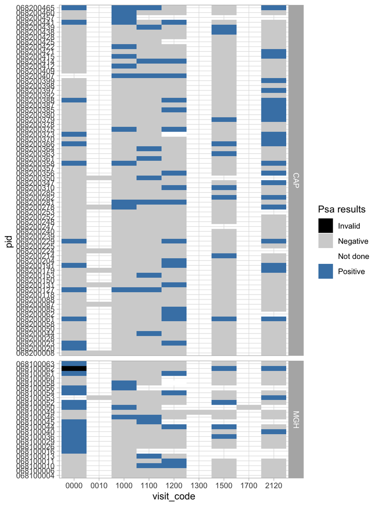

```r
sex |>
  filter(randomized) |>
  filter(!is.na(psa_results)) |>
  ggplot() +
  aes(x = visit_code, y = pid, fill = psa_results) +
  geom_tile() +
  facet_grid(site ~ ., scales = "free_y", space = "free") +
  scale_fill_manual(
    values = c(
      "Negative" = "lightgray",
      "Positive" = "steelblue",
      "Not done" = "white",
      "Invalid" = "black"
    )
  )
```

### Self-reported sexual activity

As mentionned above, self-reported sexual activity is measured in the daily diary and at the weekly visits. We have the following source of information :

- From the daily CRF (CRF33) :
  - `sex_past_24hours.crf33` : self-reported sexual behaviour in the past 24 hours (between visit 1000 and 1500). Participants answer the question “Did you had sex in the past 24 hours” every day.
  - `condom_use.crf33` : if yes to the previous question, did you use a condom ? (Always, Sometimes, Never)
  - `lubricant_use` : if yes to the first question, did you use lubricant ? (Always, Sometimes, Never)
  - `sex_type` : if yes to the first question, what type of sex ? (Oral, Anal, Vaginal, Other)
- From the weekly CRF (CRF20) :
  - `past_week_sex_partner` : self-reported sexual behaviour in the past week (at visit 1000, 1100, 1200, 1300, 1400 and 1500). Participants answer the question “In the past week, did you have sex with any of the following : a single male partner, multiple male partners, a single female partner, multiple female partners, both, no sex in the past week.
  - `sex_past_24hours.crf20` : self-reported sexual behaviour in the past 24 hours (each weekly visits). Participants answer the question “Did you had sex in the past 24 hours”.
  - `use_condom` : self-reported condom use in the past week (at visit 1000, 1100, 1200, 1300, 1400 and 1500).

#### Daily responses

We first explore the daily responses from CRF33. We are interested in the sexual behaviour of the participants. We look at whether they reported having had sexual intercourse in the last 24 hours, and whether they used lubricant and condoms.

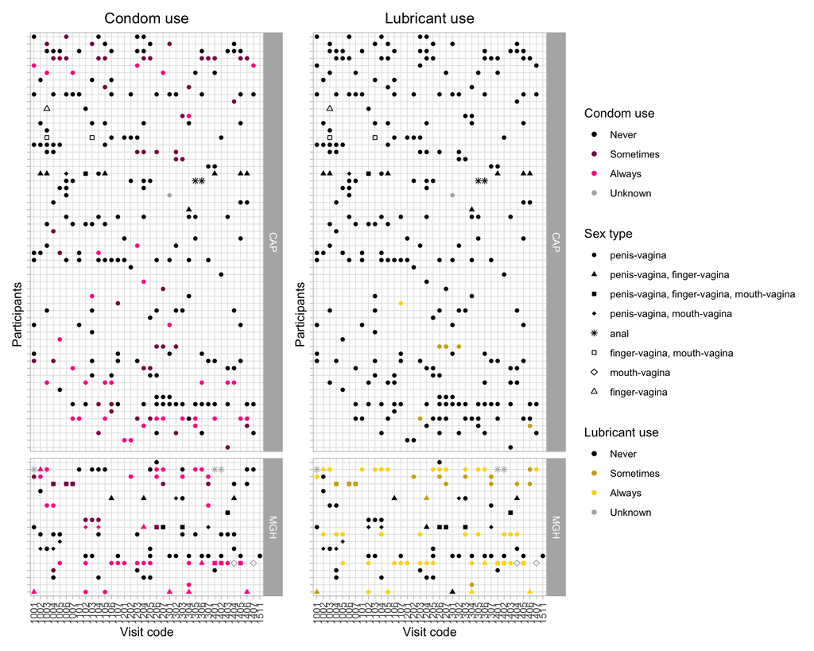

```r
p1 <-
  sex |>
  filter(sex_past_24hours.crf33 == "Yes") |>
  filter(randomized) |>
  #mutate(pid = pid |> as.character() |> factor(levels = all_pids) |> fct_infreq() |> fct_rev()) |>
  ggplot() +
  aes(
    x = visit_code |> factor(),
    y = pid,
    col = condom_use.crf33,
    shape = sex_type
  ) +
  geom_point() +
  facet_grid(site ~ ., scales = "free_y", space = "free") +
  scale_color_manual(
    "Condom use",
    values = c(
      "Never" = "black",
      "Sometimes" = "deeppink4",
      "Always" = "deeppink1",
      "Unknown" = "gray70"
    )
  ) +
  scale_shape_manual(values = c(16, 17, 15, 18, 8, 22, 5, 2)) +
  scale_y_discrete(drop = FALSE) +
  labs(
    x = "Visit code",
    y = "Participants",
    shape = "Sex type",
    title = "Condom use"
  ) +
  theme(
    axis.text.y = element_blank(),
    axis.text.x = element_text(angle = 90, hjust = 1, vjust = 0.5),
    plot.title = element_text(hjust = 0.5)
  )

p2 <-
  sex |>
  filter(sex_past_24hours.crf33 == "Yes") |>
  filter(randomized) |>
  #mutate(pid = pid |> as.character() |> factor(levels = all_pids) |> fct_infreq() |> fct_rev()) |>
  ggplot() +
  aes(
    x = visit_code |> factor(),
    y = pid,
    col = lubricant_use,
    shape = sex_type
  ) +
  geom_point() +
  facet_grid(site ~ ., scales = "free_y", space = "free") +
  scale_color_manual(
    "Lubricant use",
    values = c(
      "Never" = "black",
      "Sometimes" = "gold3",
      "Always" = "gold",
      "Unknown" = "gray70"
    )
  ) +
  scale_shape_manual(values = c(16, 17, 15, 18, 8, 22, 5, 2)) +
  scale_y_discrete(drop = FALSE) +
  labs(
    x = "Visit code",
    y = "Participants",
    shape = "Sex type",
    title = "Lubricant use"
  ) +
  theme(
    axis.text.y = element_blank(),
    axis.text.x = element_text(angle = 90, hjust = 1, vjust = 0.5),
    plot.title = element_text(hjust = 0.5)
  )

(p1 + p2) +
  plot_layout(guides = "collect") &
  theme(legend.position = "right")
```

We look at the relationship between condom use, lubricant use and sex. All participants that reported no sex in the past 24 hours reported “Blank” for condom use and lubricant use. Participants that reported having sex in the past 24 hours reported mainly “Never” for condom use and lubricant use.

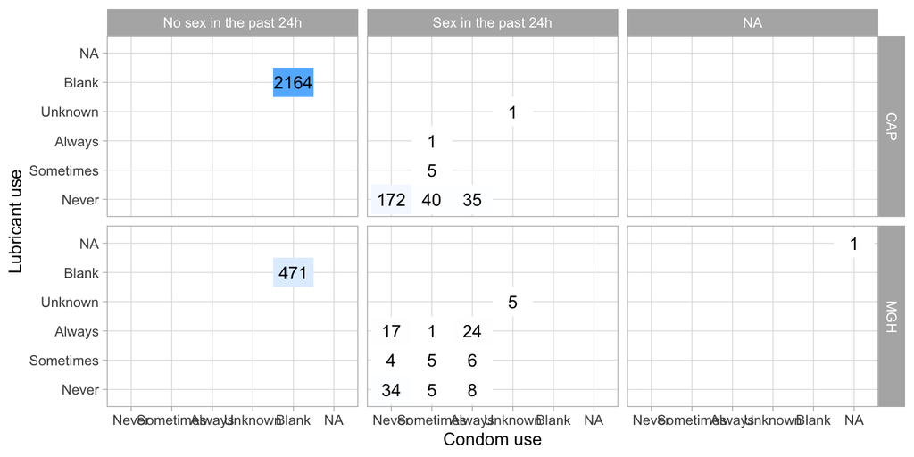

```r
sex |>
  mutate(visit_code = visit_code |> as.numeric()) |>
  filter(visit_type == "Home") |>
  filter(randomized) |>
  dplyr::count(site, sex_past_24hours.crf33, condom_use.crf33, lubricant_use) |>
  ggplot() +
  geom_tile(aes(x = condom_use.crf33, y = lubricant_use, fill = n)) +
  geom_text(aes(x = condom_use.crf33, y = lubricant_use, label = n)) +
  scale_fill_gradient(low = "white", high = "steelblue1") +
  facet_grid(
    site ~ sex_past_24hours.crf33,
    labeller = as_labeller(c(
      "No" = "No sex in the past 24h",
      "Yes" = "Sex in the past 24h",
      "MGH" = "MGH",
      "CAP" = "CAP"
    ))
  ) +
  labs(x = "Condom use", y = "Lubricant use") +
  guides(fill = "none")
```

We look at the relationship between condom use, sex type and sex. All participants that reported no sex in the past 24 hours reported “Blank” for condom use and “NA” for sex type. Participants that reported having sex in the past 24 hours reported mainly “Never” for condom use and “Vaginal” for sex type.

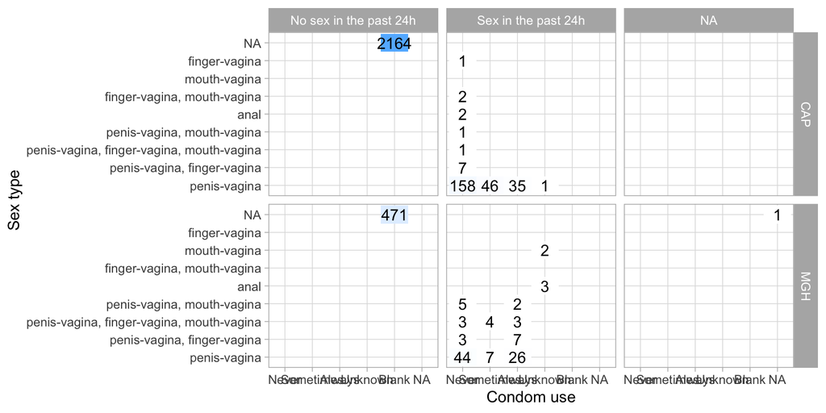

```r
sex |>
  mutate(visit_code = visit_code |> as.numeric()) |>
  filter(visit_type == "Home") |>
  filter(randomized) |>
  dplyr::count(site, sex_past_24hours.crf33, condom_use.crf33, sex_type) |>
  ggplot() +
  geom_tile(aes(x = condom_use.crf33, y = sex_type, fill = n)) +
  geom_text(aes(x = condom_use.crf33, y = sex_type, label = n)) +
  scale_fill_gradient(low = "white", high = "steelblue1") +
  facet_grid(
    site ~ sex_past_24hours.crf33,
    labeller = as_labeller(c(
      "No" = "No sex in the past 24h",
      "Yes" = "Sex in the past 24h",
      "MGH" = "MGH",
      "CAP" = "CAP"
    ))
  ) +
  labs(x = "Condom use", y = "Sex type") +
  guides(fill = "none")
```

```r
sex |>
  filter(!is.na(sex_past_24hours.crf33)) |>
  filter(randomized) |>
  filter(condom_use.crf33 == "Unknown" | lubricant_use == "Unknown") |>
  select(
    pid,
    visit_code,
    sex_past_24hours.crf33,
    sex_type,
    condom_use.crf33,
    lubricant_use
  ) |>
  gt(caption = "Zoom on unknown condom/lubricant use")
```

Zoom on unknown condom/lubricant use

| pid | visit_code | Have you had sex in the past 24 hours | sex_type | condom_use.crf33 | lubricant_use |
| --- | --- | --- | --- | --- | --- |
| 068100029 | 1404 | Yes | mouth-vagina | Unknown | Unknown |
| 068100029 | 1407 | Yes | mouth-vagina | Unknown | Unknown |
| 068100062 | 1001 | Yes | anal | Unknown | Unknown |
| 068100062 | 1401 | Yes | anal | Unknown | Unknown |
| 068100062 | 1402 | Yes | anal | Unknown | Unknown |
| 068200361 | 1301 | Yes | penis-vagina | Unknown | Unknown |

#### Weekly response

At the clinical visits, participants were ask about her sexual behavior in the last 24 hours (`sex_past_24hours.crf20`) and in the past week : her partner in the last week (`past_week_sex_partner`) and if there use use condom in the past week (`use_condom`).

We first look at the past week sex partner and the condom use.

```r
sex |>
  filter(visit_type == "Clinic") |>
  filter(randomized) |>
  select(pid, visit_code, past_week_sex_partner) |>
  distinct() |>
  dplyr::count(visit_code, past_week_sex_partner) |>
  pivot_wider(
    names_from = past_week_sex_partner,
    values_from = n,
    values_fill = 0
  ) |>
  gt(caption = "Past week sex partner by visit")
```

Past week sex partner by visit

| visit_code | NA | No sex in the past week | A single male partner | Multiple male partners |
| --- | --- | --- | --- | --- |
| 0000 | 96 | 0 | 0 | 0 |
| 1000 | 0 | 44 | 52 | 0 |
| 1100 | 2 | 52 | 42 | 0 |
| 1200 | 5 | 47 | 42 | 0 |
| 1300 | 6 | 45 | 41 | 0 |
| 1400 | 4 | 51 | 35 | 1 |
| 1500 | 3 | 57 | 31 | 0 |
| 1700 | 5 | 43 | 42 | 0 |
| 1900 | 1 | 54 | 33 | 0 |
| 2120 | 2 | 46 | 40 | 0 |

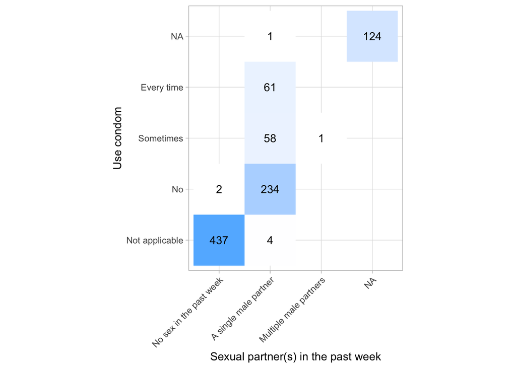

```r
sex |>
  filter(visit_type == "Clinic") |>
  filter(randomized) |>
  select(pid, visit_code, past_week_sex_partner, condom_use.crf20) |>
  distinct() |>
  dplyr::count(past_week_sex_partner, condom_use.crf20) |>
  ggplot() +
  aes(x = past_week_sex_partner, y = condom_use.crf20, fill = n) +
  geom_tile() +
  geom_text(aes(label = n)) +
  scale_fill_gradient(low = "white", high = "steelblue1") +
  guides(fill = "none") +
  labs(y = "Use condom", x = "Sexual partner(s) in the past week") +
  theme(
    strip.text = element_text(size = 12),
    axis.text.x = element_text(angle = 45, hjust = 1)
  ) +
  coord_fixed()
```

We look at the variable sex in the last 24hours (`sex_past_24hour.crf20`). We can see that the variable is not encoded as in the daily CRF. Here the variable is encoded as the “sex.type” variable.

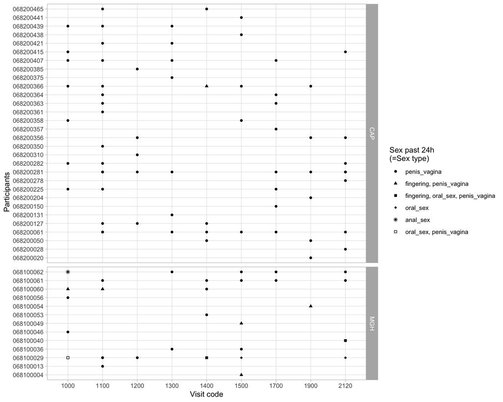

```r
sex |>
  filter(visit_type == "Clinic") |>
  filter(randomized) |>
  filter(sex_past_24hours.crf20 != "No") |>
  ggplot() +
  aes(x = visit_code |> as.factor(), y = pid, shape = sex_past_24hours.crf20) +
  geom_point() +
  facet_grid(site ~ ., scales = "free_y", space = "free") +
  scale_shape_manual(values = c(16, 17, 15, 18, 8, 22, 5, 2)) +
  labs(
    x = "Visit code",
    y = "Participants",
    shape = "Sex past 24h\n(=Sex type)"
  )
```

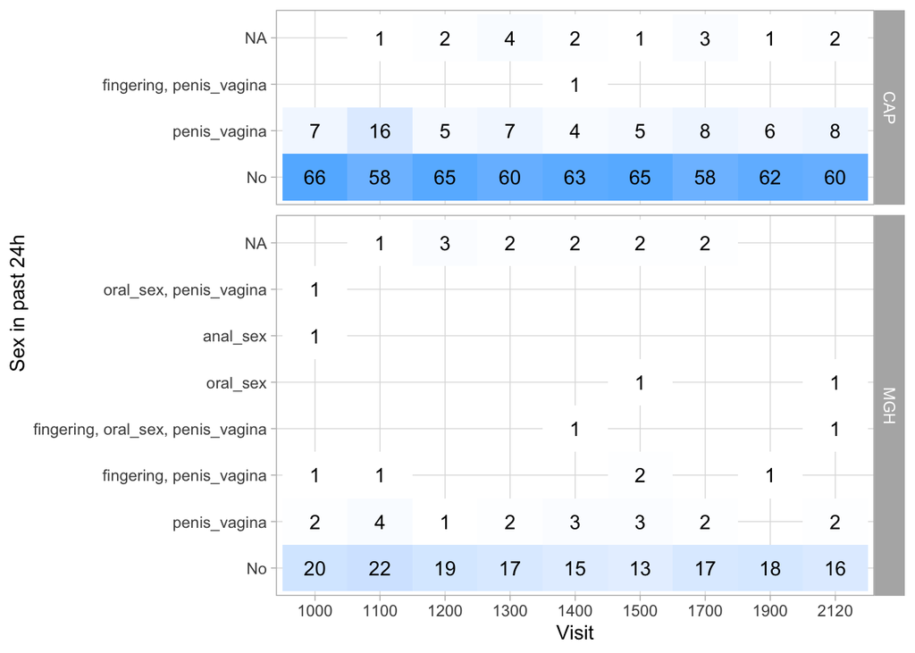

```r
sex |>
  filter(visit_type == "Clinic", visit_code != "0000", visit_code != "0010") |>
  filter(randomized) |>
  dplyr::count(site, visit_code, sex_past_24hours.crf20) |>
  ggplot() +
  aes(y = sex_past_24hours.crf20, x = visit_code |> as_factor()) +
  geom_tile(aes(fill = n)) +
  geom_text(aes(label = n)) +
  facet_grid(site ~ ., scales = "free_y", space = "free") +
  scale_fill_gradient(low = "white", high = "steelblue1") +
  labs(y = "Sex in past 24h", x = "Visit") +
  guides(fill = "none")
```

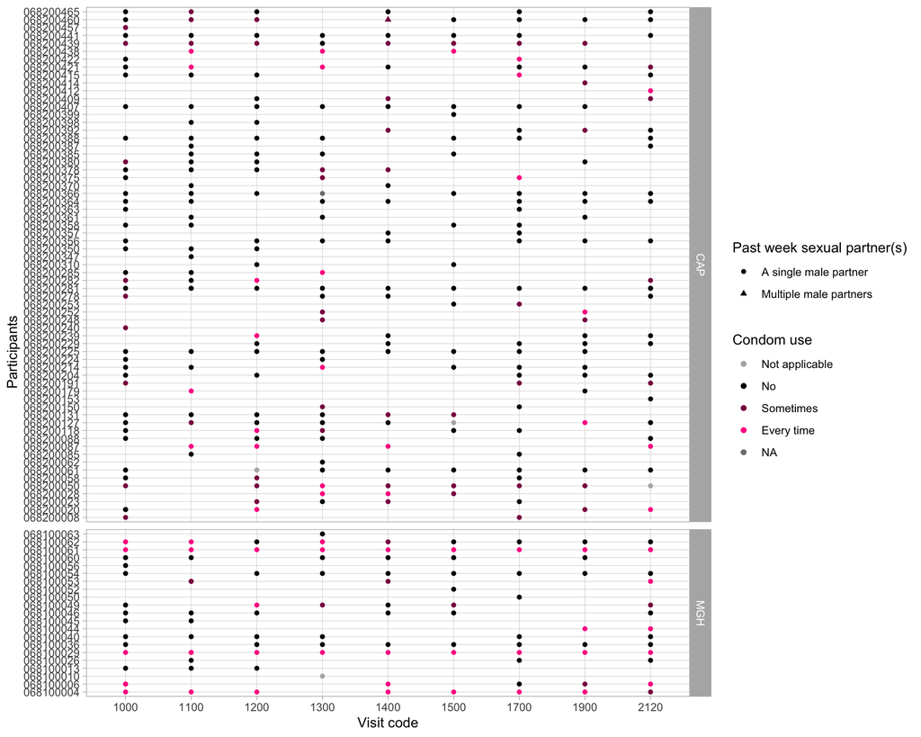

```r
sex |>
  filter(visit_type == "Clinic") |>
  filter(randomized) |>
  filter(!str_detect(past_week_sex_partner, "No")) |>
  ggplot() +
  aes(
    x = visit_code |> as.factor(),
    y = pid,
    shape = past_week_sex_partner,
    col = condom_use.crf20
  ) +
  geom_point() +
  facet_grid(site ~ ., scales = "free_y", space = "free") +
  scale_shape_manual(values = c(16, 17)) +
  scale_color_manual(
    "Condom use",
    values = c(
      "No" = "black",
      "Sometimes" = "deeppink4",
      "Every time" = "deeppink1",
      "Not applicable" = "gray70"
    )
  ) +
  labs(
    x = "Visit code",
    y = "Participants",
    shape = "Past week sexual partner(s)",
    col = "Condom use in the past week"
  )
```

Finaly we look at the consitency between `past_week_sex_partner` and `sex_past_24hours.crf20`. If participant report “Yes” to `sex_past_24hours.crf20`, they should not report “No sex in the past week” to `past_week_sex_partner`. All gray symbols in the plot below should be empty circles (if they reported Not having sex in the past week, they should report “No” to `sex_past_24hours.crf20`). We can see that there are some inconsistencies in the data. All colored symbols should be different from empty circles (if they reported having sex in the past week, they should report a type of sex to `sex_past_24hours.crf20`). We can see that there are some inconsistencies in the data.

**Note**

Is it possible that the inconsistencies are due to the fact that the question “Did you have sex in the past 24 hours” refers to the 24 hours before the visit, while the question “In the past week, did you have sex with any of the following” refers to the past week and not the 7 days before the visit ?

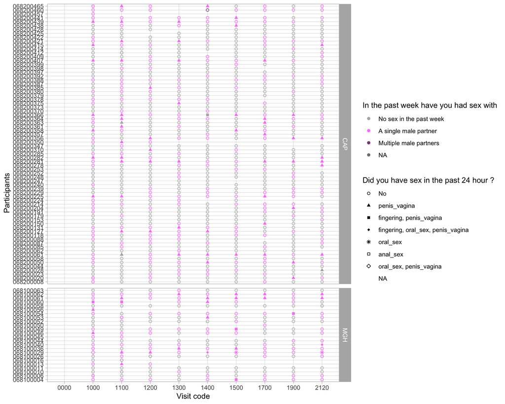

```r
sex |>
  filter(visit_type == "Clinic") |>
  filter(randomized) |>
  #filter(sex_past_24hours.crf20 !="No") |>
  ggplot() +
  aes(
    x = visit_code |> as.factor(),
    y = pid,
    shape = sex_past_24hours.crf20,
    colour = past_week_sex_partner
  ) +
  geom_point() +
  facet_grid(site ~ ., scales = "free_y", space = "free") +
  scale_shape_manual(values = c(1, 17, 15, 18, 8, 22, 5, 2)) +
  scale_color_manual(values = c("gray70", "orchid1", "orchid4")) +
  labs(
    x = "Visit code",
    y = "Participants",
    shape = "Did you have sex in the past 24 hour ?",
    col = "In the past week have you had sex with"
  )
```

```r
sex |>
  filter(visit_type == "Clinic") |>
  group_by(visit_code) |>
  dplyr::count(
    (sex_past_24hours.crf20 != "No" & !is.na(sex_past_24hours.crf20)) &
      past_week_sex_partner == "No sex in the past week"
  )
```

[output not shown]

#### Harmonization between daily and weekly responses

We merged the information from sex_past_24hours from the daily CRF (CRF33) and the weekly crf (CRF20) in one single variable `sex_past_24hours`.

`sex_past_24hours` take the value of `sex_past_24hours.crf33` for the daily responses and take the value “Yes” if `sex_past_24hours.crf20` is not “No” or missing for the weekly responses. We also harmonized the value of `sex_type`for the clinical and home visits. Since we don’t have information about condom use in the weekly CRF, if `sex_past_24hours.crf20` is not “No”, we set `condom_use.crf33` to “Unknown” for those visits. Same for `lubricant_use`.

```r
# Harmonizing daily and weekly responses
# merged daily and weekly
# sex_past_24hours in the weekly crf20 is encoded as the sex_type
# we also complete the sex_type variable with this information

sex <-
  sex |>
  mutate(
    sex_past_24hours = case_when(
      !is.na(sex_past_24hours.crf33) ~ sex_past_24hours.crf33,
      !is.na(sex_past_24hours.crf20) & sex_past_24hours.crf20 != "No" ~ "Yes",
      !is.na(sex_past_24hours.crf20) & sex_past_24hours.crf20 == "No" ~ "No",
      TRUE ~ NA_character_
    ),

    condom_use = case_when(
      !is.na(sex_past_24hours.crf20) &
        sex_past_24hours.crf20 != "No" ~ "Unknown",
      TRUE ~ condom_use.crf33
    ),

    lubricant_use = case_when(
      !is.na(sex_past_24hours.crf20) &
        sex_past_24hours.crf20 != "No" ~ "Unknown",
      TRUE ~ lubricant_use
    ),

    sex_type = case_when(
      sex_past_24hours.crf20 == "penis_vagina" ~ "penis-vagina",
      sex_past_24hours.crf20 == "oral_sex" ~ "mouth-vagina",
      sex_past_24hours.crf20 == "fingering, penis_vagina" ~ "penis-vagina, finger-vagina",
      sex_past_24hours.crf20 == "oral_sex, penis_vagina" ~ "penis-vagina, mouth-vagina",
      sex_past_24hours.crf20 ==
        "fingering, oral_sex, penis_vagina" ~ "penis-vagina, finger-vagina, mouth-vagina",
      sex_past_24hours.crf20 == "anal_sex" ~ "anal",
      TRUE ~ sex_type
    )
  )

#check
sex |>
  dplyr::count(
    sex_past_24hours,
    sex_past_24hours.crf33,
    sex_past_24hours.crf20,
    sex_type
  ) |>
  gt() |>
  cols_label(
    sex_past_24hours = "sex_past_24hours (harmonized)",
    sex_past_24hours.crf33 = "sex_past_24hours (CRF33 - daily)",
    sex_past_24hours.crf20 = "sex_past_24hours (CRF20 - weekly)",
    sex_type = "sex_type",
    n = "Count"
  )
```

| sex_past_24hours (harmonized) | sex_past_24hours (CRF33 - daily) | sex_past_24hours (CRF20 - weekly) | sex_type | Count |
| --- | --- | --- | --- | --- |
| No | No | No | NA | 2 |
| No | No | NA | NA | 2649 |
| No | NA | No | NA | 713 |
| Yes | Yes | NA | anal | 5 |
| Yes | Yes | NA | finger-vagina | 1 |
| Yes | Yes | NA | finger-vagina, mouth-vagina | 2 |
| Yes | Yes | NA | mouth-vagina | 2 |
| Yes | Yes | NA | penis-vagina | 319 |
| Yes | Yes | NA | penis-vagina, finger-vagina | 17 |
| Yes | Yes | NA | penis-vagina, finger-vagina, mouth-vagina | 11 |
| Yes | Yes | NA | penis-vagina, mouth-vagina | 8 |
| Yes | NA | penis_vagina | penis-vagina | 85 |
| Yes | NA | fingering, penis_vagina | penis-vagina, finger-vagina | 6 |
| Yes | NA | fingering, oral_sex, penis_vagina | penis-vagina, finger-vagina, mouth-vagina | 2 |
| Yes | NA | oral_sex | mouth-vagina | 2 |
| Yes | NA | anal_sex | anal | 1 |
| Yes | NA | oral_sex, penis_vagina | penis-vagina, mouth-vagina | 1 |
| NA | NA | NA | NA | 693 |

Some participants have the same `study_day` for both a clinic visit and a home (daily diary) visit. This occurs when a clinical visit and a daily diary entry fall on the same calendar day. In those cases, we have two rows for the same participant and study day, with potentially conflicting information on sexual behaviour.

We identified 374 such duplicated `(pid, study_day)` pairs, involving 93 participants.

To resolve these duplicates, we apply the following priority rules and keep one row per `(pid, study_day)` :

- **`sex_past_24hours`** : if the clinic visit reports `Yes`, it overrides a `No` from the daily diary (the clinical visit is considered more reliable in case of conflict). Otherwise, the daily diary value prevails.
- **`condom_use` / `sex_type`** : follow the same priority as `sex_past_24hours`.
- **`psa_results`** : always taken from the clinic visit.
- **`visit_code`** : kept from the clinic visit.
- **`visit_type`** : set to `"Clinic & Home"` when both exist.

```r
# Display values of duplicate study_day for a participant

sex |>
  dplyr::count(pid, study_day) |>
  filter(n > 1) |>
  left_join(sex, by = c("pid", "study_day")) |>
  select(pid, study_day, sex_past_24hours, condom_use, sex_type, psa_results) |>
  arrange(pid, study_day) |>
  gt(caption = "Duplicated (pid, study_day) before harmonisation")
```

[output not shown]

```r
sex <-
  sex |>
  group_by(pid, study_day) |>
  mutate(
    # Sex : Clinic prime si Clinic = Yes, sinon Home prime
    sex_past_24hours = case_when(
      any(visit_type == "Clinic" & sex_past_24hours == "Yes") ~ "Yes",
      any(visit_type == "Home") ~ sex_past_24hours[visit_type == "Home"][1],
      TRUE ~ sex_past_24hours[1]
    ),

    # Condom : si Clinic a forcé sex = Yes → Unknown, sinon Home prime
    condom_use = case_when(
      any(visit_type == "Clinic" & sex_past_24hours == "Yes") &
        any(visit_type == "Home" & sex_past_24hours == "No") ~ "Unknown", # Clinic a primé
      any(visit_type == "Home" & sex_past_24hours == "Yes") ~ condom_use[
        visit_type == "Home" & sex_past_24hours == "Yes"
      ][1],
      TRUE ~ condom_use[1]
    ),

    # Sex type : même logique que condom
    sex_type = case_when(
      any(visit_type == "Clinic" & sex_past_24hours == "Yes") &
        any(visit_type == "Home" & sex_past_24hours == "No") ~ sex_type[
        visit_type == "Clinic"
      ][1],
      any(visit_type == "Home" & sex_past_24hours == "Yes") ~ sex_type[
        visit_type == "Home" & sex_past_24hours == "Yes"
      ][1],
      TRUE ~ sex_type[1]
    ),

    # PSA toujours depuis Clinic
    psa_results = case_when(
      any(visit_type == "Clinic") ~ psa_results[visit_type == "Clinic"][1],
      TRUE ~ psa_results[1]
    ),

    # Metadata : visit_code Clinic, visit_type concaténé si doublon
    visit_code = case_when(
      any(visit_type == "Clinic") ~ visit_code[visit_type == "Clinic"][1],
      TRUE ~ visit_code[1]
    ),
    visit_type = case_when(
      n() > 1 ~ "Clinic & Home",
      TRUE ~ visit_type[1]
    )
  ) |>
  dplyr::slice(1) |> # une seule ligne par (pid, study_day)
  ungroup()


# Vérifier les cas Clinic & Home
sex |>
  filter(visit_type == "Clinic & Home") |>
  dplyr::count(sex_past_24hours, condom_use) |>
  gt(
    caption = "Duplicated (pid, study_day) after harmonisation - Clinic & Home"
  ) |>
  cols_label(
    sex_past_24hours = "Sex in past 24h (harmonized)",
    condom_use = "Condom use (harmonized)",
    n = "Count"
  )
```

Duplicated (pid, study_day) after harmonisation - Clinic & Home

| Sex in past 24h (harmonized) | Condom use (harmonized) | Count |
| --- | --- | --- |
| No | Blank | 7 |
| No | NA | 321 |
| Yes | Always | 7 |
| Yes | Blank | 13 |
| Yes | Never | 18 |
| Yes | Sometimes | 3 |
| Yes | Unknown | 3 |
| NA | NA | 2 |

#### Comparing daily and weekly responses

**Note**

For instance, the inconsistency are just reported but no action is taken to resolve them.

We first look at the consitency between the variable `sex_past_24hours` from CRF33 and the variable `past_week_sex_partner` from CRF20. If participant report “Yes” to `sex_past_24hours`, they should not report “No sex in the past week” to `past_week_sex_partner`.

```r
sex |>
  filter(!is.na(visit_code)) |>
  ggplot() +
  aes(x = visit_code, y = pid) +
  geom_point(
    data = sex |>
      filter(sex_past_24hours.crf33 == "Yes"),
    aes(fill = sex_past_24hours.crf33),
    size = 2.5,
    alpha = 0.5,
    shape = 21
  ) +
  geom_point(
    data = sex |>
      filter(!is.na(past_week_sex_partner)),
    aes(color = past_week_sex_partner),
    size = 2.5
  ) +
  scale_fill_manual(
    name = "Sex in past 24h",
    values = c("Yes" = "orchid1", "No" = "white")
  ) +
  scale_color_manual(
    name = "Sex partner past week",
    values = c(
      "No sex in the past week" = "grey80",
      "A single male partner" = "orchid1",
      "Multiple male partners" = "orchid3"
    )
  ) +
  labs(x = "Visit", y = "Participant ID") +
  theme(axis.text.x = element_text(angle = 45, hjust = 1))
```

[output not shown]

```r
daily_summary <-
  sex |>
  filter(visit_type %in% c("Home", "Clinic & Home")) |>
  mutate(period = str_sub(visit_code, 1, 2)) |>
  group_by(pid, period) |>
  summarise(
    any_daily_sex = any(sex_past_24hours.crf33 == "Yes", na.rm = TRUE),
    all_daily_no_sex = all(sex_past_24hours.crf33 == "No", na.rm = TRUE),
    n_daily_visits = n(),
    .groups = "drop"
  )


sex |>
  filter(visit_type == "Clinic") |>
  mutate(period = str_sub(visit_code, 1, 2)) |>
  select(pid, period, past_week_sex_partner) |>
  left_join(daily_summary, by = c("pid", "period")) |>
  filter(period < 16 & period != "00") |>
  mutate(
    inconsistency_1 = any_daily_sex &
      (past_week_sex_partner == "No sex in the past week"),
    inconsistency_2 = all_daily_no_sex &
      (past_week_sex_partner != "No sex in the past week")
  ) |>
  dplyr::count(inconsistency_1, inconsistency_2) |>
  gt(
    caption = "Table of inconsistencies between daily and weekly sexual behaviour reports between visits 1000 and 1500"
  ) |>
  cols_label(
    inconsistency_1 = "Daily sex but no weekly",
    inconsistency_2 = "Weekly sex but no daily",
    n = "Count"
  )
```

Table of inconsistencies between daily and weekly sexual behaviour reports between visits 1000 and 1500

| Daily sex but no weekly | Weekly sex but no daily | Count |
| --- | --- | --- |
| FALSE | FALSE | 85 |
| FALSE | TRUE | 22 |
| FALSE | NA | 21 |
| TRUE | FALSE | 16 |
| NA | FALSE | 45 |
| NA | NA | 13 |

We do the same with the condom use. At the weekly clinical visits, participants were ask if they used condom in the past week (In the past week, if you had male partners, did you use condoms? - `use_condom`). This should be consistent with the daily reports of condom use in the past 24 hours.

```r
sex |>
  filter(!is.na(visit_code)) |>
  ggplot() +
  aes(x = visit_code, y = pid) +
  geom_point(
    data = sex |>
      mutate(
        condom_daily = ifelse(
          condom_use.crf33 %in% c("Always", "Sometimes"),
          "Yes",
          "No"
        )
      ) |>
      filter(condom_daily == "Yes"),
    aes(fill = condom_daily),
    size = 2.5,
    alpha = 0.5,
    shape = 21
  ) +
  geom_point(
    data = sex |>
      mutate(
        condom_weekly = ifelse(
          condom_use.crf20 %in% c("Every time", "Sometimes"),
          "Yes",
          "No"
        )
      ) |>
      filter(condom_weekly == "Yes"),
    aes(color = condom_weekly),
    size = 2.5
  ) +
  labs(x = "Visit", y = "Participant ID") +
  theme(axis.text.x = element_text(angle = 45, hjust = 1))
```

[output not shown]

```r
daily_summary <-
  sex |>
  filter(visit_type %in% c("Home", "Clinic & Home")) |>
  mutate(period = str_sub(visit_code, 1, 2)) |>
  group_by(pid, period) |>
  summarise(
    any_daily_condom = any(
      condom_use.crf33 %in% c("Always", "Sometimes"),
      na.rm = TRUE
    ),
    all_daily_no_condom = all(
      condom_use.crf33 %in% c("Never", "Unknown", "Blank"),
      na.rm = TRUE
    ),
    n_daily_visits = n(),
    .groups = "drop"
  )


sex |>
  filter(visit_type == "Clinic") |>
  mutate(period = str_sub(visit_code, 1, 2)) |>
  select(pid, period, condom_use.crf20) |>
  mutate(
    past_week_condom = case_when(
      condom_use.crf20 %in%
        c("Every time", "Sometimes") ~ "Yes condom in past week",
      condom_use.crf20 %in%
        c("Never", "Not applicable") ~ "No condom in past week",
      TRUE ~ NA_character_
    )
  ) |>
  left_join(daily_summary, by = c("pid", "period")) |>
  filter(period < 16 & period != "00") |>
  mutate(
    inconsistency_1 = any_daily_condom &
      (past_week_condom == "No condom in past week"),
    inconsistency_2 = all_daily_no_condom &
      (past_week_condom == "Yes condom in past week")
  ) |>
  dplyr::count(inconsistency_1, inconsistency_2) |>
  gt(
    caption = "Table of inconsistencies between daily and weekly condom use reports between visits 1000 and 1500"
  ) |>
  cols_label(
    inconsistency_1 = "Any condom use daily but no reported weekly",
    inconsistency_2 = "No condom use daily but reported weekly",
    n = "Count"
  )
```

Table of inconsistencies between daily and weekly condom use reports between visits 1000 and 1500

| Any condom use daily but no reported weekly | No condom use daily but reported weekly | Count |
| --- | --- | --- |
| FALSE | FALSE | 59 |
| FALSE | TRUE | 10 |
| FALSE | NA | 51 |
| TRUE | FALSE | 7 |
| NA | FALSE | 50 |
| NA | NA | 25 |

#### SF Semen Exposure Variables

Since our final goal is to assess semen exposure, we create boolean summary variables for the self - declared semen exposure.

*Note : pv is for penis-vagina*

If a participant have FALSE values for all the SF variables, it means they did not have any sexual activity in the past 24 hours.

```r
# Creating SF_semen_exposure

sex <-
  sex |>
  mutate(
    SF_pv_sex_w_semen_exposure = sex_past_24hours == "Yes" &
      str_detect(sex_type, "penis-vagina") &
      (condom_use == "Never" | condom_use == "Sometimes"),
    SF_pv_sex_wo_semen_exposure = sex_past_24hours == "Yes" &
      str_detect(sex_type, "penis-vagina") &
      condom_use == "Always",
    SF_pv_sex_unknown_semen_exposure = sex_past_24hours == "Yes" &
      str_detect(sex_type, "penis-vagina") &
      (is.na(condom_use) | condom_use == "Unknown" | condom_use == "Blank"),
    SF_other_sex_wo_semen_exposure = sex_past_24hours == "Yes" &
      str_detect(sex_type, "finger-vagina|mouth-vagina|anal")
  )

# check
sex |>
  dplyr::count(
    sex_past_24hours,
    sex_type,
    condom_use,
    SF_pv_sex_w_semen_exposure,
    SF_pv_sex_wo_semen_exposure,
    SF_pv_sex_unknown_semen_exposure,
    SF_other_sex_wo_semen_exposure
  ) |>
  gt(caption = "Table of self-reported semen exposure variables") |>
  cols_label(
    sex_past_24hours = "Sex in\npast 24h",
    condom_use = "Condom\nuse",
    sex_type = "Sex type",
    SF_pv_sex_w_semen_exposure = "SF pv sex w\nsemen exposure",
    SF_pv_sex_wo_semen_exposure = "SF pv sex wo\nsemen exposure",
    SF_pv_sex_unknown_semen_exposure = "SF pv sex unknown\nsemen exposure",
    SF_other_sex_wo_semen_exposure = "SF other sex wo\nsemen exposure",
    n = "Count"
  )
```

Table of self-reported semen exposure variables

| Sex in past 24h | Sex type | Condom use | SF pv sex w semen exposure | SF pv sex wo semen exposure | SF pv sex unknown semen exposure | SF other sex wo semen exposure | Count |
| --- | --- | --- | --- | --- | --- | --- | --- |
| No | NA | Blank | FALSE | FALSE | FALSE | FALSE | 2316 |
| No | NA | NA | FALSE | FALSE | FALSE | FALSE | 712 |
| Yes | anal | Never | FALSE | FALSE | FALSE | TRUE | 2 |
| Yes | anal | Unknown | FALSE | FALSE | FALSE | TRUE | 4 |
| Yes | finger-vagina | Never | FALSE | FALSE | FALSE | TRUE | 1 |
| Yes | finger-vagina, mouth-vagina | Never | FALSE | FALSE | FALSE | TRUE | 2 |
| Yes | mouth-vagina | Unknown | FALSE | FALSE | FALSE | TRUE | 3 |
| Yes | penis-vagina | Always | FALSE | TRUE | FALSE | FALSE | 61 |
| Yes | penis-vagina | Never | TRUE | FALSE | FALSE | FALSE | 203 |
| Yes | penis-vagina | Sometimes | TRUE | FALSE | FALSE | FALSE | 53 |
| Yes | penis-vagina | Unknown | FALSE | FALSE | TRUE | FALSE | 51 |
| Yes | penis-vagina, finger-vagina | Always | FALSE | TRUE | FALSE | TRUE | 7 |
| Yes | penis-vagina, finger-vagina | Never | TRUE | FALSE | FALSE | TRUE | 10 |
| Yes | penis-vagina, finger-vagina | Unknown | FALSE | FALSE | TRUE | TRUE | 4 |
| Yes | penis-vagina, finger-vagina, mouth-vagina | Always | FALSE | TRUE | FALSE | TRUE | 3 |
| Yes | penis-vagina, finger-vagina, mouth-vagina | Never | TRUE | FALSE | FALSE | TRUE | 4 |
| Yes | penis-vagina, finger-vagina, mouth-vagina | Sometimes | TRUE | FALSE | FALSE | TRUE | 4 |
| Yes | penis-vagina, finger-vagina, mouth-vagina | Unknown | FALSE | FALSE | TRUE | TRUE | 1 |
| Yes | penis-vagina, mouth-vagina | Always | FALSE | TRUE | FALSE | TRUE | 2 |
| Yes | penis-vagina, mouth-vagina | Never | TRUE | FALSE | FALSE | TRUE | 6 |
| Yes | penis-vagina, mouth-vagina | Unknown | FALSE | FALSE | TRUE | TRUE | 1 |
| Yes | NA | Blank | FALSE | FALSE | NA | NA | 13 |
| NA | NA | NA | NA | NA | NA | NA | 682 |

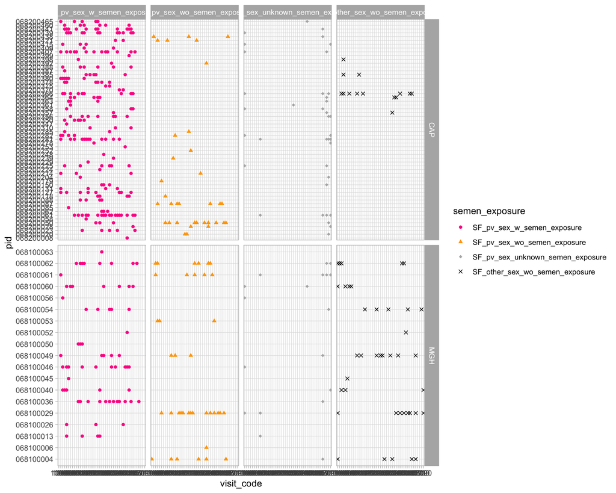

```r
sex |>
  pivot_longer(
    cols = starts_with("SF_"),
    names_to = "semen_exposure",
    values_to = "value"
  ) |>
  filter(value == TRUE) |>
  mutate(
    semen_exposure = semen_exposure |>
      factor(
        levels = c(
          "SF_pv_sex_w_semen_exposure",
          "SF_pv_sex_wo_semen_exposure",
          "SF_pv_sex_unknown_semen_exposure",
          "SF_other_sex_wo_semen_exposure"
        )
      )
  ) |>
  ggplot() +
  aes(y = pid, x = visit_code, col = semen_exposure, shape = semen_exposure) +
  geom_point() +
  facet_grid(site ~ semen_exposure, scales = "free_y") +
  scale_color_manual(values = c("deeppink", "orange", "gray70", "black")) +
  scale_shape_manual(values = c(16, 17, 18, 4))
```

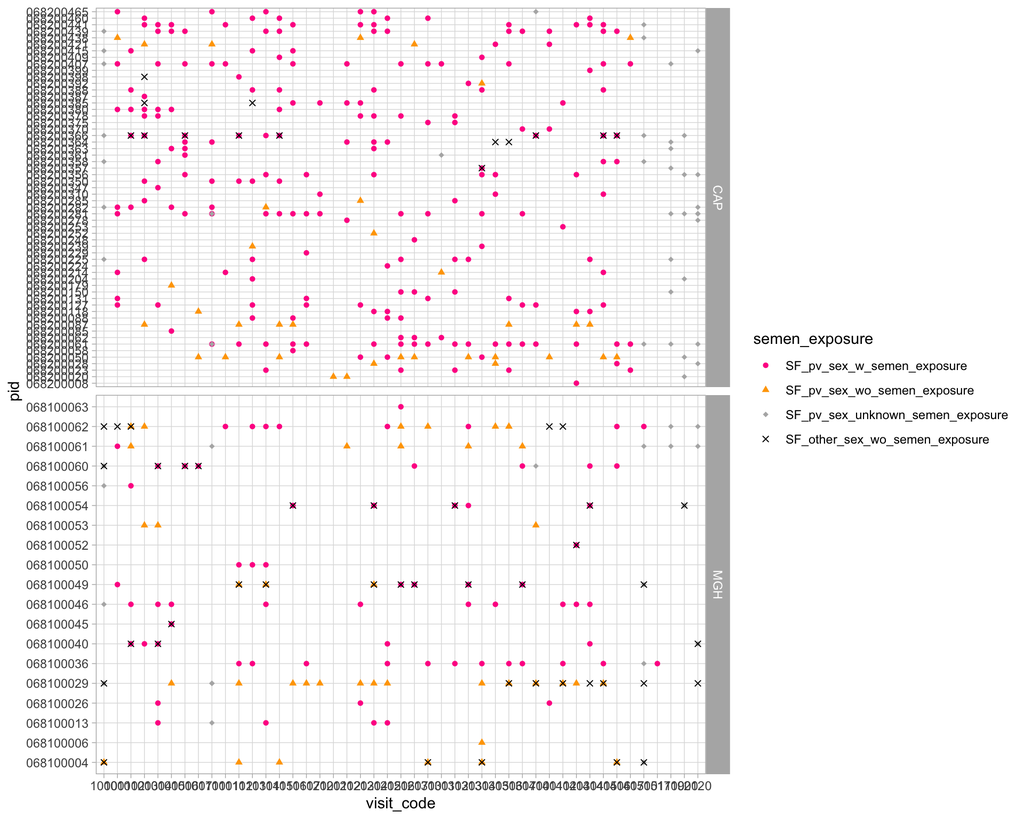

```r
sex |>
  pivot_longer(
    cols = starts_with("SF_"),
    names_to = "semen_exposure",
    values_to = "value"
  ) |>
  filter(value == TRUE) |>
  mutate(
    semen_exposure = semen_exposure |>
      factor(
        levels = c(
          "SF_pv_sex_w_semen_exposure",
          "SF_pv_sex_wo_semen_exposure",
          "SF_pv_sex_unknown_semen_exposure",
          "SF_other_sex_wo_semen_exposure"
        )
      )
  ) |>
  ggplot() +
  aes(y = pid, x = visit_code, col = semen_exposure, shape = semen_exposure) +
  geom_point() +
  facet_grid(site ~ ., scales = "free_y") +
  scale_color_manual(values = c("deeppink", "orange", "gray70", "black")) +
  scale_shape_manual(values = c(16, 17, 18, 4))
```

We created new variables to assess the time since last sexual intercourse (with or without condom) at each study day using the `sex_past_24hours` and `condom_use` variables.

- `sf_day_since_last_sex_w_cndm` : count the number of day since the last self-report (penis-vagina) sexual intercourse with condom.
- `sf_days_since_last_sex_wo_cndm` : count the number of day since the last self-report (penis-vagina) sexual intercourse without condom.
- `sf_days_since_last_sex_unknown_cndm` : count the number of day since the last self-report (penis-vagina) sexual intercourse with unknown condom use.

**Note**

We don’t have the information about the last sexual intercourse for the first visits until the first reported sexual intercourse. `day_since_last_sex` remains NA until the first reported sexual intercourse.

Should I impute the last sexual intercourse for the first visit (1000) ? A solution could be to look at the variable `sexual_partners_past_month` and `sex_past_24hours` collected at the beginning of the study. If the participant reported no sexual partners in the last month and no sexual activity in the past 24 hours, we could impute the last sexual intercourse as 30 days before the visit. If the participant reported having a sexual partner in the last month but no sexual activity in the past 24 hours, we could impute the last sexual intercourse as 15 days before the visit.

```r
# Approximate the last sexual intercourse before the study start

sex <-
  sex |>
  arrange(pid, study_day) |>
  group_by(pid) |>
  mutate(
    # with condom only
    last_sex_day_w_cndm = case_when(
      sex_past_24hours == "Yes" &
        str_detect(sex_type, "penis-vagina") &
        condom_use == "Always" ~ study_day,
      TRUE ~ NA_integer_
    ),
    last_sex_day_w_cndm = zoo::na.locf(last_sex_day_w_cndm, na.rm = FALSE),
    sf_days_since_last_sex_w_cndm = study_day - last_sex_day_w_cndm,

    # without condom only
    last_sex_day_wo_cndm = case_when(
      sex_past_24hours == "Yes" &
        str_detect(sex_type, "penis-vagina") &
        (condom_use == "Never" | condom_use == "Sometimes") ~ study_day,
      TRUE ~ NA_integer_
    ),
    last_sex_day_wo_cndm = zoo::na.locf(last_sex_day_wo_cndm, na.rm = FALSE),
    sf_days_since_last_sex_wo_cndm = study_day - last_sex_day_wo_cndm,

    # unknown condom use
    last_sex_day_unknown_cndm = case_when(
      sex_past_24hours == "Yes" &
        str_detect(sex_type, "penis-vagina") &
        (is.na(condom_use) |
          condom_use == "Unknown" |
          condom_use == "Blank") ~ study_day,
      TRUE ~ NA_integer_
    ),
    last_sex_day_unknown_cndm = zoo::na.locf(
      last_sex_day_unknown_cndm,
      na.rm = FALSE
    ),
    sf_days_since_last_sex_unknown_cndm = study_day - last_sex_day_unknown_cndm
  ) |>
  ungroup() |>
  select(
    -c(last_sex_day_wo_cndm, last_sex_day_w_cndm, last_sex_day_unknown_cndm)
  )
```

Numbers and colors represent the number of day since the last sexual intercourse without condom

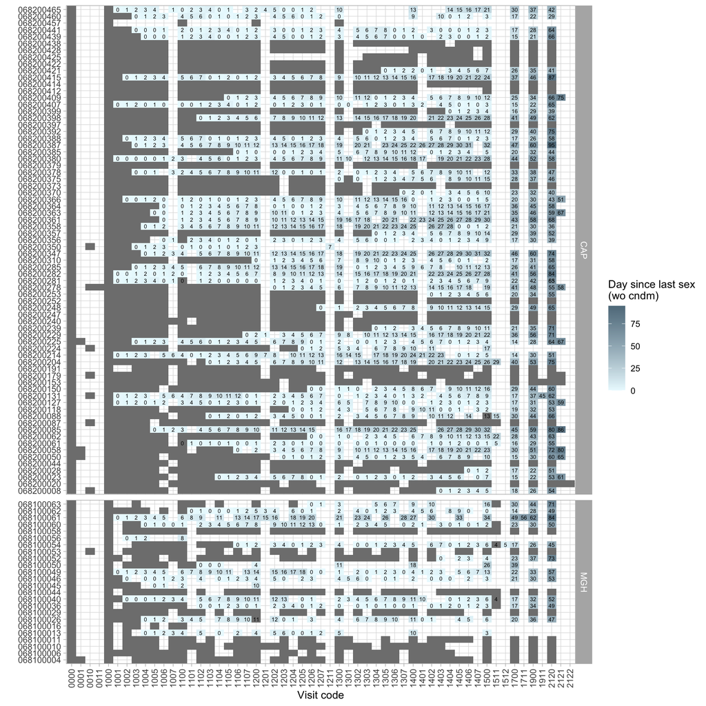

```r
sex |>
  filter(randomized) |>
  ggplot() +
  aes(
    x = visit_code |> as.factor(),
    y = pid,
    fill = sf_days_since_last_sex_wo_cndm
  ) +
  geom_tile() +
  facet_grid(site ~ ., scales = "free_y", space = "free") +
  geom_text(aes(label = sf_days_since_last_sex_wo_cndm), size = 2) +
  scale_fill_gradient(
    "Day since last sex\n(wo cndm)",
    low = "#EBFAFE",
    high = "lightskyblue4"
  ) +
  labs(x = "Visit code", y = "") +
  theme(
    #axis.text.y = element_blank(),
    axis.text.x = element_text(angle = 90, hjust = 1, vjust = 0.5)
  )
```

### Comparison of PSA and SF sexual activity

We compare the PSA results and the self-reported sexual behavior (`SF_pv_sex_w_semen_exposure` and `SF_pv_sex_unknown_semen_exposure`) to look at the consistency between those two variables.

Each time a participant report a sexual intercourse in the past 24h with semen exposure (either known or unknown), we plot a point on the graph. Each time a participant have a positive PSA result, we plot a cross on the graph. We can see that some of the positive PSA results are consistent with self-reported sexual activity with semen exposure, but there are some inconsistencies (positive PSA without self-reported sexual activity with semen exposure and vice versa).

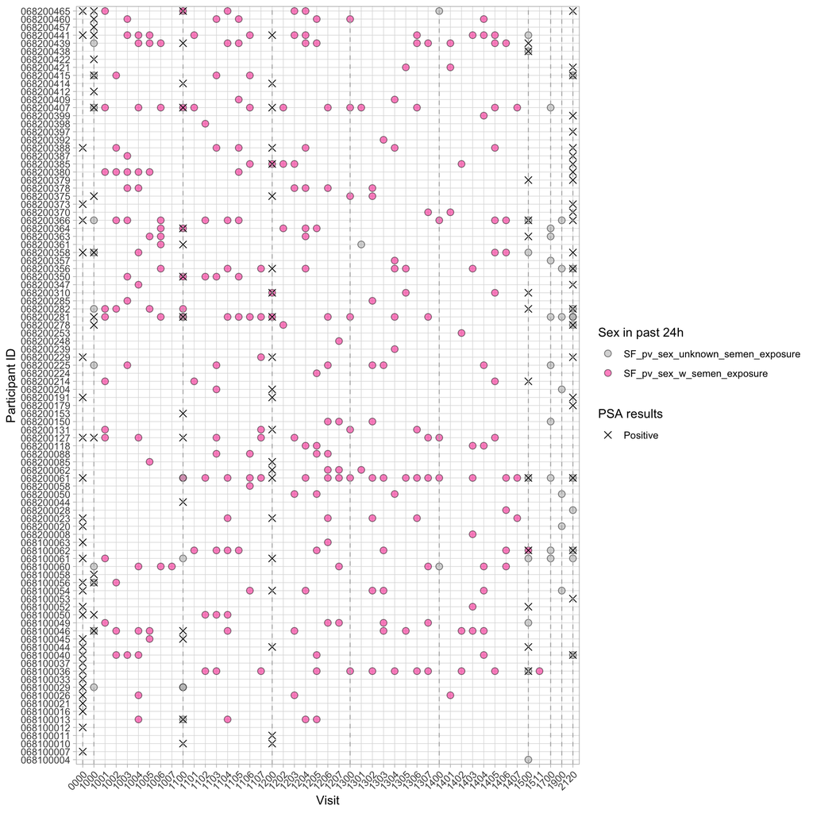

```r
sex |>
  filter(!is.na(visit_code)) |>
  filter(randomized) |>
  ggplot() +
  aes(x = visit_code, y = pid) +
  geom_point(
    data = sex |>
      filter(SF_pv_sex_w_semen_exposure | SF_pv_sex_unknown_semen_exposure) |>
      pivot_longer(
        cols = c(SF_pv_sex_w_semen_exposure, SF_pv_sex_unknown_semen_exposure),
        names_to = "semen_exposure",
        values_to = "value"
      ) |>
      filter(value == TRUE),
    aes(fill = semen_exposure),
    size = 2.5,
    alpha = 0.5,
    shape = 21
  ) +
  geom_point(
    data = sex |>
      filter(psa_results == "Positive"),
    aes(shape = psa_results),
    size = 2.5
  ) +
  geom_vline(
    data = sex |>
      select(visit_code, visit_type) |>
      filter(visit_type == "Clinic") |>
      distinct(),
    aes(xintercept = visit_code),
    color = "gray70",
    linetype = "dashed",
    linewidth = 0.4
  ) +
  scale_fill_manual(
    name = "Sex in past 24h",
    values = c("gray70", "deeppink"),
  ) +
  scale_shape_manual(
    name = "PSA results",
    values = c("Positive" = 4)
  ) +
  labs(x = "Visit", y = "Participant ID") +
  theme(axis.text.x = element_text(angle = 45, hjust = 1))
```

#### Table of PSA and SF-sex

We take into account the time since last sexual intercourse and look at the consistency between PSA results and self-reported sexual behaviour depending on the time since last sexual intercourse.

We don’t take into account the visit 0000 since we don’t have information about their sexual behaviour : CRF33 and CRF20 where not fill at that visit. We just have information about PSA and we imputed the day since last sex using this information.

**Note**

Some participants that have a PSA positive but a day since last sex > 4 had report, at that weekly visit, a sexual intercourse in the last 24h BUT for the weekly visit we don’t have the information about the condom use (so the variable `day_since_last_sex_wo_cndm`was not update)

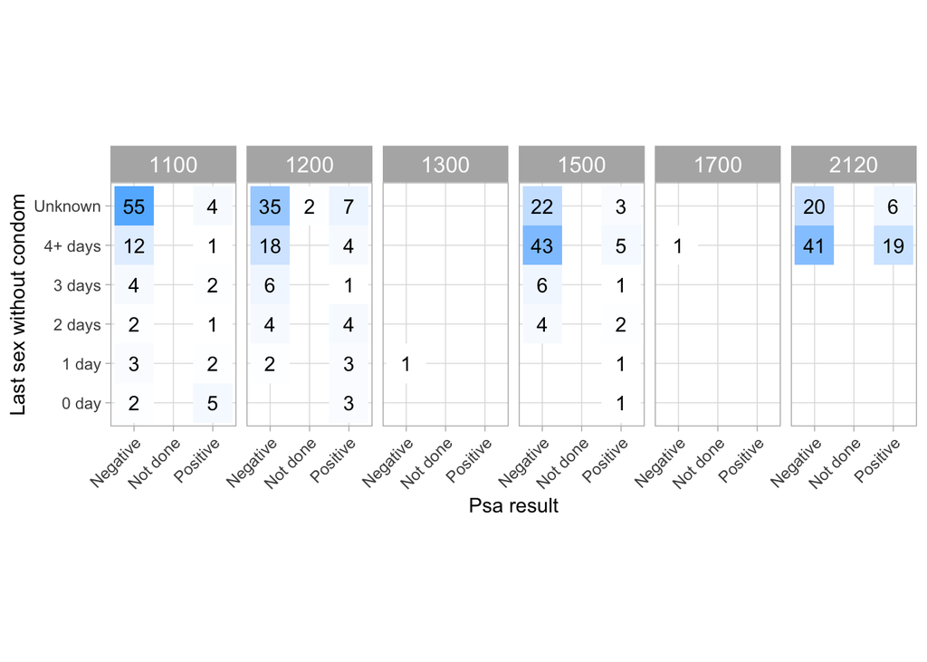

```r
sex |>
  #filter(randomized) |>
  filter(visit_type %in% c("Clinic", "Clinic & Home")) |>
  group_by(pid) |>
  mutate(
    last_sex_wo_cndm_cat = case_when(
      is.na(sf_days_since_last_sex_wo_cndm) ~ "Unknown",
      sf_days_since_last_sex_wo_cndm == 0 ~ "0 day",
      sf_days_since_last_sex_wo_cndm == 1 ~ "1 day",
      sf_days_since_last_sex_wo_cndm == 2 ~ "2 days",
      sf_days_since_last_sex_wo_cndm == 3 ~ "3 days",
      sf_days_since_last_sex_wo_cndm >= 4 ~ "4+ days",
      TRUE ~ NA_character_
    )
  ) |>
  ungroup() |>
  select(pid, visit_code, last_sex_wo_cndm_cat, psa_results, visit_type) |>
  distinct() |>
  filter(
    visit_type %in% c("Clinic", "Clinic & Home"),
    visit_code > "0000",
    visit_code != "1000"
  ) |>
  filter(!is.na(psa_results)) |>
  dplyr::count(visit_code, last_sex_wo_cndm_cat, psa_results) |>
  ggplot(aes(x = psa_results, y = last_sex_wo_cndm_cat, fill = n)) +
  geom_tile() +
  facet_grid(~visit_code) +
  geom_text(aes(label = n)) +
  scale_fill_gradient(low = "white", high = "steelblue1") +
  ylab("Last sex without condom") +
  xlab("Psa result") +
  guides(fill = "none") +
  theme(
    strip.text = element_text(size = 12),
    axis.text.x = element_text(angle = 45, hjust = 1)
  ) +
  coord_fixed()
```

Let’s do the same plot but taking the variable `day_since_last_sex_unknown_cndm` to account for the fact that at the weekly visit we don’t have information about the condom use. If a participant reported a sexual intercourse in the last 24h at the weekly visit, we set the variable `day_since_last_sex_unknown_cndm` to 0 for that visit, even if we don’t know if they used condom or not.

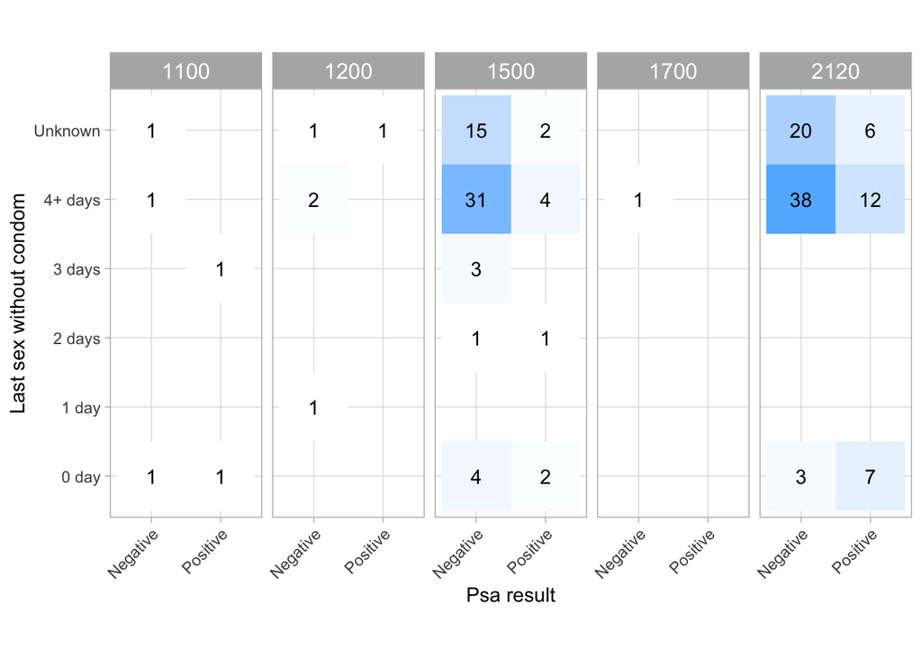

```r
sex |>
  filter(randomized) |>
  filter(visit_type == "Clinic") |>
  group_by(pid) |>
  mutate(
    last_sex_wo_cndm_cat = case_when(
      is.na(sf_days_since_last_sex_wo_cndm) ~ "Unknown",
      sf_days_since_last_sex_wo_cndm == 0 |
        sf_days_since_last_sex_unknown_cndm == 0 ~ "0 day",
      sf_days_since_last_sex_wo_cndm == 1 |
        sf_days_since_last_sex_unknown_cndm == 1 ~ "1 day",
      sf_days_since_last_sex_wo_cndm == 2 |
        sf_days_since_last_sex_unknown_cndm == 2 ~ "2 days",
      sf_days_since_last_sex_wo_cndm == 3 |
        sf_days_since_last_sex_unknown_cndm == 3 ~ "3 days",
      sf_days_since_last_sex_wo_cndm >= 4 |
        sf_days_since_last_sex_unknown_cndm >= 4 ~ "4+ days",
      TRUE ~ NA_character_
    )
  ) |>
  ungroup() |>
  select(pid, visit_code, last_sex_wo_cndm_cat, psa_results, visit_type) |>
  distinct() |>
  filter(visit_type == "Clinic", visit_code > "0000", visit_code != "1000") |>
  filter(!is.na(psa_results)) |>
  dplyr::count(visit_code, last_sex_wo_cndm_cat, psa_results) |>
  ggplot(aes(x = psa_results, y = last_sex_wo_cndm_cat, fill = n)) +
  geom_tile() +
  facet_grid(~visit_code) +
  geom_text(aes(label = n)) +
  scale_fill_gradient(low = "white", high = "steelblue1") +
  ylab("Last sex without condom") +
  xlab("Psa result") +
  guides(fill = "none") +
  theme(
    strip.text = element_text(size = 12),
    axis.text.x = element_text(angle = 45, hjust = 1)
  ) +
  coord_fixed()
```

### Summary variable for semen exposure

Three numeric variables are created to summarize self-reported sexual behaviour, each taking a value between 0 and 1 where **0** indicates no event, **1** indicates a confirmed event, and **0.5** indicates a possible or uncertain event :

- `pv_sex_w_semen_exposure` : penile-vaginal sex with semen exposure
- `pv_sex_wo_semen_exposure` : penile-vaginal sex without semen exposure
- `other_sex_wo_semen_exp` : other type of sexual activity without semen exposure

The two latter variables are derived directly from their boolean counterparts (`SF_pv_sex_wo_semen_exposure` and `SF_other_sex_wo_semen_exposure`), converted to numeric (FALSE → 0, TRUE → 1). The first variable, `pv_sex_w_semen_exposure`, follows the same base conversion from `SF_pv_sex_w_semen_exposure` but is further refined using PSA results to resolve ambiguous self-reports :

- If `SF_pv_sex_unknown_semen_exposure` is TRUE and the PSA result is **positive**, semen exposure is considered possible (`pv_sex_w_semen_exposure` = 0.5). If the PSA result is **negative**, the event is instead recorded as sex without semen exposure (`pv_sex_wo_semen_exposure` = 1).
- If `pv_sex_w_semen_exposure` is still 0 but a **positive PSA** is recorded on the same day or within the two following days, semen exposure is considered possible (= 0.5), since PSA can remain detectable up to 3 days after a sexual intercourse with semen exposure.

```r
psa_correction_days <-
  sex |>
  filter(psa_results == "Positive") |>
  select(pid, study_day) |>
  reframe(
    correction_day = c(study_day, study_day - 1, study_day - 2),
    .by = c(pid, study_day)
  ) |>
  select(pid, correction_day) |>
  distinct() |>
  mutate(psa_positive_nearby = TRUE)

sex <-
  sex |>
  mutate(
    # conversion booléen → numérique
    pv_sex_w_semen_exposure = as.numeric(SF_pv_sex_w_semen_exposure == TRUE),
    pv_sex_wo_semen_exposure = as.numeric(SF_pv_sex_wo_semen_exposure == TRUE),
    other_sex_wo_semen_exp = as.numeric(SF_other_sex_wo_semen_exposure == TRUE),

    # Résolution du "unknown" aux visites weekly avec le PSA
    pv_sex_w_semen_exposure = case_when(
      SF_pv_sex_unknown_semen_exposure & psa_results == "Positive" ~ 0.5,
      TRUE ~ pv_sex_w_semen_exposure
    ),
    pv_sex_wo_semen_exposure = case_when(
      SF_pv_sex_unknown_semen_exposure & psa_results == "Negative" ~ 1,
      TRUE ~ pv_sex_wo_semen_exposure
    )
  ) |>

  # Correction PSA pour les jours entourant un PSA positif
  left_join(
    psa_correction_days,
    by = c("pid", "study_day" = "correction_day")
  ) |>
  mutate(
    pv_sex_w_semen_exposure = case_when(
      psa_positive_nearby & pv_sex_w_semen_exposure == 0 ~ 0.5,
      TRUE ~ pv_sex_w_semen_exposure
    )
  ) |>
  select(-psa_positive_nearby)
```

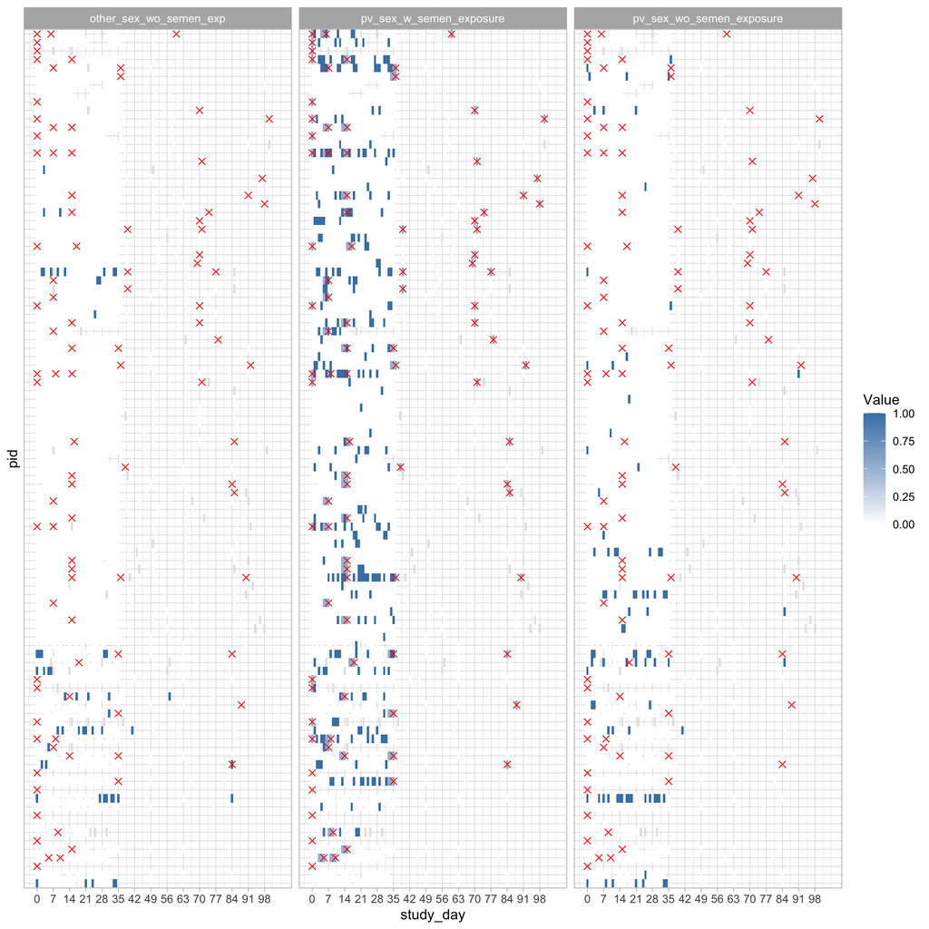

```r
sex |>
  filter(randomized, study_day >= 0) |>
  pivot_longer(
    cols = c(
      pv_sex_w_semen_exposure,
      pv_sex_wo_semen_exposure,
      other_sex_wo_semen_exp
    ),
    names_to = "variable",
    values_to = "value"
  ) |>
  ggplot(aes(x = study_day, y = pid, fill = value)) +
  geom_tile() +
  # Overlay PSA positif
  geom_point(
    data = sex |> filter(psa_results == "Positive", study_day >= 0),
    aes(x = study_day, y = pid),
    inherit.aes = FALSE,
    shape = 4,
    size = 2,
    color = "red"
  ) +
  facet_grid(. ~ variable, scales = "free_y") +
  scale_fill_gradient(
    "Value",
    low = "white",
    high = "steelblue",
    na.value = "grey90"
  ) +
  scale_x_continuous(breaks = seq(0, 100, by = 7)) +
  theme(
    axis.text.y = element_blank(),
    axis.ticks.y = element_blank()
  )
```

### Adding semen exposure variables to the metadata

We add the summary variables for sexual activity and semen exposure to the `calc_vars_study_day` table in the metadata of the `mae` object.

```r
mae@metadata$calc_vars_study_day <-
  mae@metadata$calc_vars_study_day |>
  left_join(
    sex |>
      select(
        pid,
        study_day,
        sex_past_24hours,
        condom_use,
        sf_days_since_last_sex_wo_cndm,
        sf_days_since_last_sex_w_cndm,
        pv_sex_w_semen_exposure,
        sf_days_since_last_sex_unknown_cndm,
        pv_sex_wo_semen_exposure,
        other_sex_wo_semen_exp
      ),
    by = join_by(pid, study_day)
  )
```

## Metronidazole exposure

```r
mtz <-
  mae@metadata$exposures |>
  select(
    uid,
    pid,
    visit_code,
    study_day,
    daily_self_reported_exposure_to_mtz,
    comments_mtz
  ) |>
  #filter(!is.na(daily_self_reported_exposure_to_mtz)) |>
  distinct()
```

Metronadizole exposure is alreay calculate in the `01a-clinical-CRF-data-cleaning.qmd` in the `exposures` table of the metadata. This variable is calculated at the `visit_code` level, and study day have not been harmonized in this table. Some participants have a value of `daily_self_reported_exposure_to_mtz` but no study day associated with this value.

```r
mtz |>
  filter(!is.na(daily_self_reported_exposure_to_mtz)) |>
  filter(is.na(study_day)) |>
  gt()
```

| uid | pid | visit_code | study_day | daily_self_reported_exposure_to_mtz | comments_mtz |
| --- | --- | --- | --- | --- | --- |
| 068100010_1001 | 068100010 | 1001 | NA | 2 | NA |
| 068100011_1001 | 068100011 | 1001 | NA | 1 | NA |
| 068100013_1001 | 068100013 | 1001 | NA | 2 | NA |
| 068100016_1001 | 068100016 | 1001 | NA | 2 | NA |
| 068100036_1001 | 068100036 | 1001 | NA | 2 | NA |
| 068100044_1001 | 068100044 | 1001 | NA | 2 | NA |
| 068100050_1001 | 068100050 | 1001 | NA | 2 | NA |
| 068100053_1001 | 068100053 | 1001 | NA | 2 | NA |
| 068100054_1001 | 068100054 | 1001 | NA | 2 | NA |
| 068100054_1002 | 068100054 | 1002 | NA | 2 | NA |
| 068100058_1001 | 068100058 | 1001 | NA | 2 | NA |
| 068100060_1001 | 068100060 | 1001 | NA | 2 | NA |
| 068100063_1001 | 068100063 | 1001 | NA | 2 | Visit on MTZ day 5; no missed doses; no follow-up visit |
| 068100063_1002 | 068100063 | 1002 | NA | 2 | Visit on MTZ day 5; no missed doses; no follow-up visit |
| 068200191_1001 | 068200191 | 1001 | NA | 2 | NA |
| 068200191_1002 | 068200191 | 1002 | NA | 2 | NA |

```r
# mtz |>
#   filter(!is.na(study_day)) |>
#   dplyr::count(pid, study_day, daily_self_reported_exposure_to_mtz) |>
#   filter(n>1) |>
#   gt(caption = "Participants with information on metronidazole exposure and study day")
```

The missing study day for those participants occurs at the visit 1001 or 1002, which is the first home visit after the study start. Those participants have no entry in the `visits_crfs_merged` table for those visits, which is why we don’t have the study day for those visits in the `exposures` table.

```r
pid_tmp <- mtz |>
  filter(!is.na(daily_self_reported_exposure_to_mtz)) |>
  filter(is.na(study_day)) |>
  pull(pid)

mtz |>
  filter(pid %in% pid_tmp) |>
  filter(visit_code %in% c("1001", "1002", "1003", "1004")) |>
  select(pid, visit_code, study_day) |>
  distinct() |>
  arrange(pid, visit_code) |>
  pivot_wider(names_from = visit_code, values_from = study_day) |>
  gt(
    caption = "Visits for participants with missing study day for metronidazole exposure"
  )
```

Visits for participants with missing study day for metronidazole exposure

| pid | 1001 | 1002 | 1003 | 1004 |
| --- | --- | --- | --- | --- |
| 068100010 | NA | 1 | 2 | 3 |
| 068100011 | NA | 2 | 3 | 4 |
| 068100013 | NA | 3 | 4 | 5 |
| 068100016 | NA | 2 | 3 | 4 |
| 068100036 | NA | 1 | 2 | 3 |
| 068100044 | NA | 1 | 2 | 3 |
| 068100050 | NA | 2 | 3 | 4 |
| 068100053 | NA | 1 | 2 | 3 |
| 068100054 | NA | NA | 2 | 3 |
| 068100058 | NA | 1 | 2 | 3 |
| 068100060 | NA | 1 | 2 | 3 |
| 068100063 | NA | NA | 2 | 3 |
| 068200191 | NA | NA | 3 | 4 |

We will use the `colData` from the `mae` object to impute the missing study day for those participants.

```r
mtz <-
  mtz |>
  filter(!is.na(daily_self_reported_exposure_to_mtz)) |>
  select(-study_day) |>
  left_join(
    mae@colData |>
      as_tibble() |>
      select(pid, visit_code, study_day) |>
      distinct(),
    by = join_by(pid, visit_code)
  )
```

There is no duplicate study day for the metronidazole variable after the imputation.

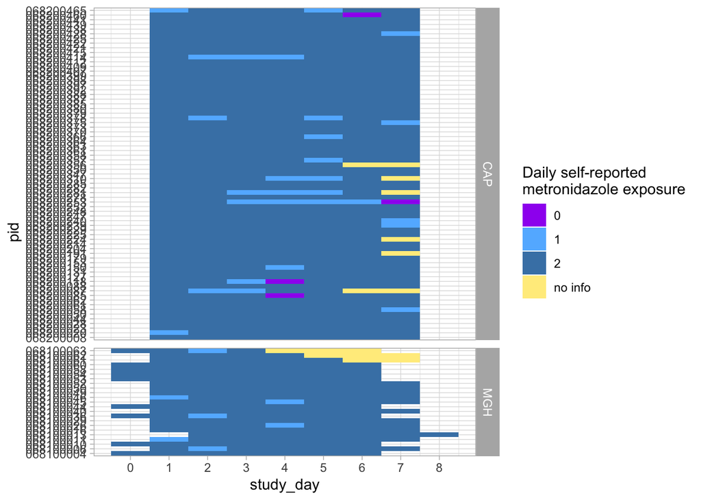

```r
mtz |>
  mutate(site = ifelse(str_detect(pid, "0681"), "MGH", "CAP")) |>
  ggplot() +
  aes(x = study_day, y = pid, fill = daily_self_reported_exposure_to_mtz) +
  geom_tile() +
  facet_grid(site ~ ., scales = "free_y", space = "free") +
  scale_x_continuous(breaks = seq(0, 10, by = 1)) +
  scale_fill_manual(
    name = "Daily self-reported\nmetronidazole exposure",
    values = c("purple", "steelblue1", "steelblue", "lightgoldenrod1")
  )
```

```r
# mtz |>
#   filter(daily_self_reported_exposure_to_mtz == "no info") |>
#   select(pid, study_day, comments_mtz) |>
#   distinct() |>
#   gt(caption = "Participants with no information on metronidazole exposure but with comments")
```

Some participants have a value of `daily_self_reported_exposure_to_mtz` equal to “no info”. We will set those values to NA since we have no information about their metronidazole exposure.

```r
mtz <-
  mtz |>
  mutate(
    daily_self_reported_exposure_to_mtz = ifelse(
      daily_self_reported_exposure_to_mtz == "no info",
      NA,
      daily_self_reported_exposure_to_mtz
    )
  )
```

### Adding metronidazole exposure variable to the metadata

We add the variable `daily_self_reported_exposure_to_mtz` and `comments_daily_self_reported_exposure_to_mtz` to the `calc_vars_study_day` table in the metadata of the `mae` object.

```r
mae@metadata$calc_vars_study_day <-
  mae@metadata$calc_vars_study_day |>
  left_join(
    mtz |>
      select(
        pid,
        study_day,
        daily_self_reported_exposure_to_mtz,
        comments_daily_self_reported_exposure_to_mtz = comments_mtz
      ) |>
      distinct(),
    by = join_by(pid, study_day)
  )
```

## Study product variables

Two study_product variable are available in the `exposures` table of the metadata of the `mae` object :

- `daily_self_reported_adherence_sp` : the self reported number of study product doses insert by the participant (0 or 1)
- `daily_self_reported_exposure_sp` : the self-reported exposure to the study product (between 0 and 1). This variable take nto account the doses that fall out.

Those variable are collected at the `visit_code` level, the goal of this analyses is to report the study product adherence and exposure at the `study_day` level.

```r
sp <-
  mae@metadata$exposures |>
  select(
    uid,
    pid,
    visit_code,
    study_day,
    daily_self_reported_adherence_sp,
    daily_self_reported_exposure_sp,
    comments_studyproduct
  ) |>
  #filter(!is.na(daily_self_reported_exposure_to_study_product)) |>
  distinct()
```

There is no missing or duplicates study day for the study product variables.

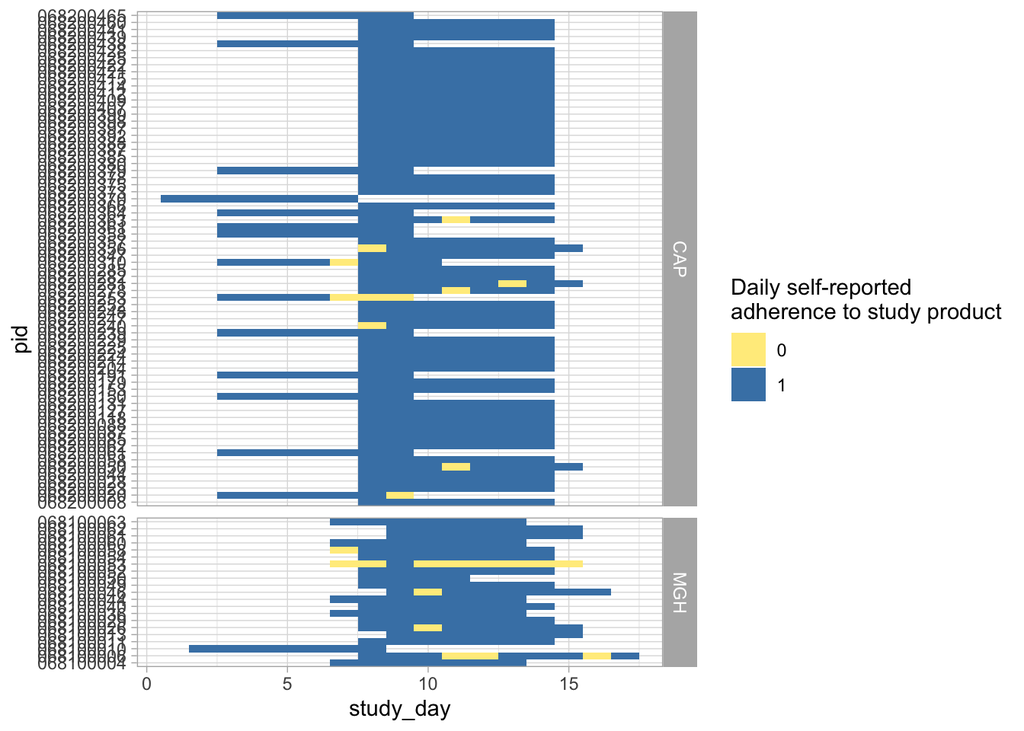

```r
sp |>
  filter(!is.na(daily_self_reported_adherence_sp)) |>
  mutate(site = ifelse(str_detect(pid, "0681"), "MGH", "CAP")) |>
  ggplot() +
  aes(
    x = study_day,
    y = pid,
    fill = daily_self_reported_adherence_sp |> factor()
  ) +
  geom_tile() +
  facet_grid(site ~ ., scales = "free_y", space = "free") +
  scale_fill_manual(
    name = "Daily self-reported\nadherence to study product",
    values = c("0" = "lightgoldenrod1", "1" = "steelblue")
  )
```

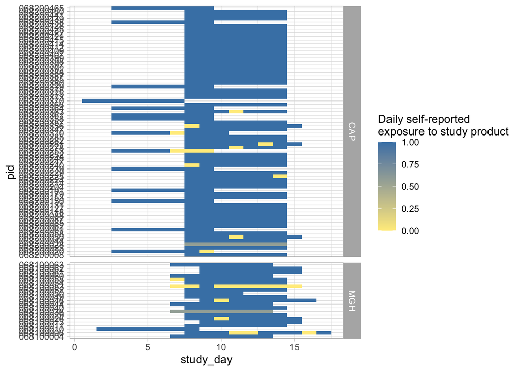

```r
sp |>
  filter(!is.na(daily_self_reported_exposure_sp)) |>
  mutate(site = ifelse(str_detect(pid, "0681"), "MGH", "CAP")) |>
  ggplot() +
  aes(x = study_day, y = pid, fill = daily_self_reported_exposure_sp) +
  geom_tile() +
  facet_grid(site ~ ., scales = "free_y", space = "free") +
  scale_fill_gradient(
    name = "Daily self-reported\nexposure to study product",
    low = "lightgoldenrod1",
    high = "steelblue",
    na.value = "grey90"
  )
```

### Adding study product variables to the metadata

We add the variable `daily_self_reported_adherence_sp`, `daily_self_reported_exposure_sp` and the `comments_daily_self_reported_exposure_sp` to the `calc_vars_study_day` table in the metadata of the `mae` object.

```r
mae@metadata$calc_vars_study_day <-
  mae@metadata$calc_vars_study_day |>
  left_join(
    sp |>
      filter(!is.na(daily_self_reported_adherence_sp)) |>
      select(
        pid,
        study_day,
        daily_self_reported_adherence_sp,
        daily_self_reported_exposure_sp,
        comments_daily_self_reported_exposure_sp = comments_studyproduct
      ) |>
      distinct(),
    by = join_by(pid, study_day)
  )
```

## Bleeding

We explore the self-reported vaginal bleeding variable by first performing an exploratory analysis for both daily and weekly responses, checking for missing values.

We have available the following informations:

- From the daily CRF (CRF33):
  - `vaginal_bleeding.crf33`: daily self-reported vaginal bleeding in the past 24 hours (between visits 1000 and 1500), excluding weekly visit codes. Participants were asked the question: “in the past 24 hours, have you experienced any vaginal bleeding?”. Possible responses were categorized into four levels:
    - `No - None`: no vaginal bleeding experienced
    - `Yes – Light`: light vaginal bleeding
    - `Yes – Medium`: moderate vaginal bleeding
    - `Yes – Heavy`: heavy vaginal bleeding
- From the weekly CRF (CRF19):
  - `vaginal_bleeding.crf19`: weekly self-reported vaginal bleeding. Participants were asked the question: “today, are you having any vaginal bleeding?”. Possible responses were categorized into four levels:
    - `No-None`: no vaginal bleeding experienced
    - `Yes–Light`: light vaginal bleeding
    - `Yes–Medium`: moderate vaginal bleeding
    - `Yes–Heavy`: heavy vaginal bleeding

All those data are available in the `visits_crfs_merged` table stored in the metadata of the `mae` object.

```r
bleeding <-
  visits_crfs_merged |>
  select(
    uid,
    pid,
    visit_code,
    study_day,
    visit_type,
    site,
    randomized,
    vaginal_bleeding.crf33,
    vaginal_bleeding.crf19
  ) |>
  arrange(pid, visit_code)
```

### Daily responses

We first look at the daily responses from CRF33.

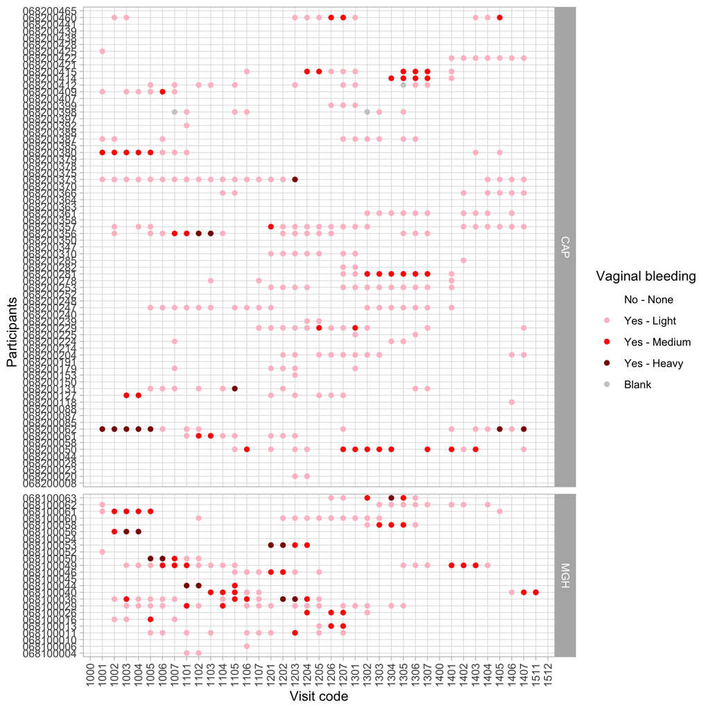

```r
bleeding |>
  filter(!is.na(vaginal_bleeding.crf33)) |>
  filter(randomized) |>
  ggplot() +
  aes(
    x = visit_code |> factor(),
    y = pid,
    col = vaginal_bleeding.crf33
  ) +
  geom_point() +
  facet_grid(site ~ ., scales = "free_y", space = "free_y") +
  scale_color_manual(
    "Vaginal bleeding",
    values = c(
      "Blank" = "gray80",
      "No - None" = "transparent",
      "Yes - Light" = "pink",
      "Yes - Medium" = "red",
      "Yes - Heavy" = "red4"
    )
  ) +
  scale_y_discrete(drop = FALSE) +
  theme(
    axis.text.x = element_text(angle = 90, hjust = 1, vjust = 0.5)
  ) +
  labs(
    x = "Visit code",
    y = "Participants"
  )
```

All `Blank` responses are participants who did not report any vaginal bleeding in the past 24 hours. We assume (for now) that no vaginal bleeding occurred at those visits.

### Weekly response

Now, we look at the variable `vaginal_bleeding` from CRF19.

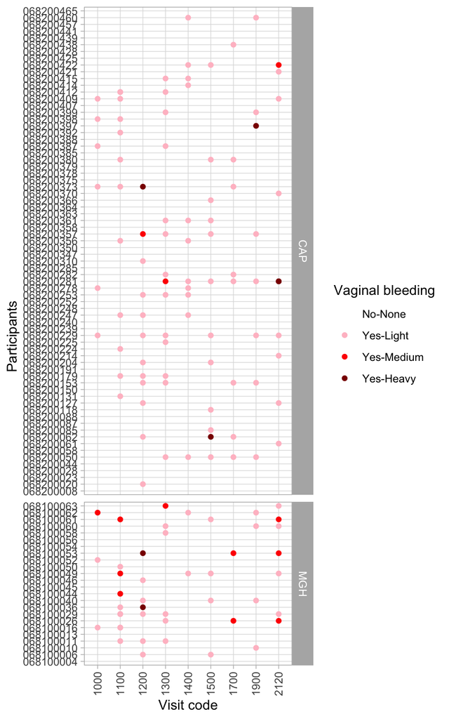

```r
bleeding |>
  filter(!is.na(vaginal_bleeding.crf19)) |>
  filter(randomized) |>
  ggplot() +
  aes(
    x = visit_code |> factor(),
    y = pid,
    col = vaginal_bleeding.crf19
  ) +
  geom_point() +
  facet_grid(site ~ ., scales = "free_y", space = "free_y") +
  scale_color_manual(
    "Vaginal bleeding",
    values = c(
      "Blank" = "gray80",
      "No-None" = "transparent",
      "Yes-Light" = "pink",
      "Yes-Medium" = "red",
      "Yes-Heavy" = "red4"
    )
  ) +
  scale_y_discrete(drop = FALSE) +
  theme(
    axis.text.x = element_text(angle = 90, hjust = 1, vjust = 0.5)
  ) +
  labs(
    x = "Visit code",
    y = "Participants"
  )
```

From the plots above, we can see that the categorical variable `vaginal_bleeding` is not encoded in the same way in `CRF33` and `CRF19`. The correction will be carried out in the next section.

### Harmonization of daily and weekly reponses

In this section, we merge the information for `vaginal_bleeding` from the daily CRF33 and the weekly CRF19 into one single variable `vaginal_bleeding`.

```r
# merge daily and weekly
# harmonize variable names
# replace "Blank" by "No-None"

bleeding <-
  bleeding |>
  mutate(
    vaginal_bleeding = coalesce(vaginal_bleeding.crf33, vaginal_bleeding.crf19),
    vaginal_bleeding = case_when(
      vaginal_bleeding %in% c("Blank") ~ "None",
      vaginal_bleeding == "No - None" | vaginal_bleeding == "No-None" ~ "None",
      vaginal_bleeding == "Yes - Light" |
        vaginal_bleeding == "Yes-Light" ~ "Light",
      vaginal_bleeding == "Yes - Medium" |
        vaginal_bleeding == "Yes-Medium" ~ "Medium",
      vaginal_bleeding == "Yes - Heavy" |
        vaginal_bleeding == "Yes-Heavy" ~ "Heavy",
      TRUE ~ vaginal_bleeding
    )
  )
```

The merged vaginal bleeding plot is displayed below.

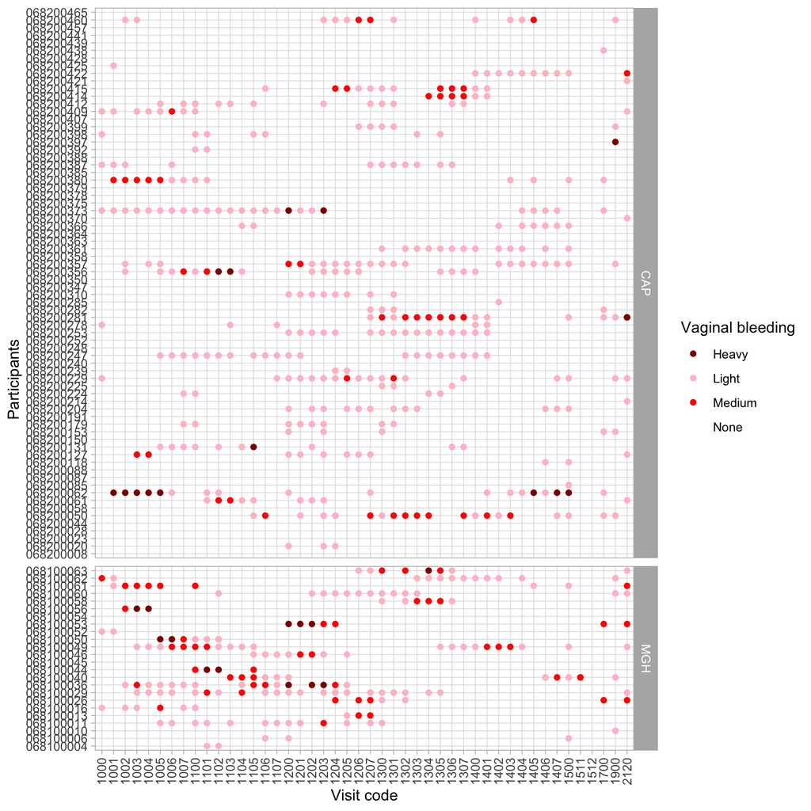

```r
bleeding |>
  filter(!is.na(vaginal_bleeding)) |>
  filter(randomized) |>
  ggplot() +
  aes(
    x = visit_code |> factor(),
    y = pid,
    col = vaginal_bleeding
  ) +
  geom_point() +
  facet_grid(site ~ ., scales = "free_y", space = "free_y") +
  scale_color_manual(
    "Vaginal bleeding",
    values = c(
      "Blank" = "gray80",
      "None" = "transparent",
      "Light" = "pink",
      "Medium" = "red",
      "Heavy" = "red4"
    )
  ) +
  scale_y_discrete(drop = FALSE) +
  theme(
    axis.text.x = element_text(angle = 90, hjust = 1, vjust = 0.5)
  ) +
  labs(
    x = "Visit code",
    y = "Participants"
  )
```

### Concatenation with study days

Multiple visit codes can correspond to the same study day when a clinical visit and a daily diary entry occur on the same calendar day. In such cases, duplicate `(pid, study_day)` pairs arise and must be resolved before analysis. For vaginal bleeding, we retain the most severe value reported across duplicate entries, following the ordinal scale: Blank < None < Light < Medium < Heavy. This conservative approach ensures that bleeding episodes are not underestimated.

We first inspect the distribution of duplicate study days across visit codes to identify the extent of the overlap.

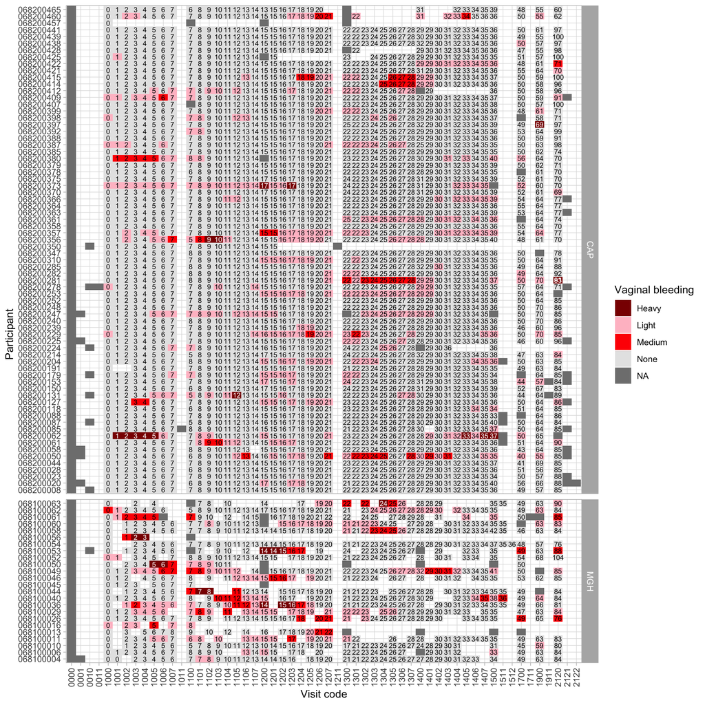

```r
bleeding |>
  filter(randomized) |>
  ggplot() +
  aes(x = visit_code, y = pid, fill = vaginal_bleeding) +
  geom_tile() +
  geom_text(
    aes(
      label = study_day,
      col = ifelse(vaginal_bleeding == "Heavy", "white", "black")
    ),
    size = 2.5
  ) +
  facet_grid(site ~ ., scales = "free_y", space = "free_y") +
  scale_fill_manual(
    "Vaginal bleeding",
    values = c(
      "None" = "grey90",
      "Light" = "pink",
      "Medium" = "red",
      "Heavy" = "red4"
    )
  ) +
  scale_color_identity() +
  theme(
    axis.text.x = element_text(angle = 90, hjust = 1, vjust = 0.5),
  ) +
  labs(x = "Visit code", y = "Participant")
```

We identified 374 duplicated `(pid, study_day)` pairs involving 93 participants. Among these, 18 pairs show inconsistent vaginal bleeding values across duplicate entries.

```r
bleeding |>
  dplyr::count(pid, study_day) |>
  filter(n > 1) |>
  left_join(bleeding, by = c("pid", "study_day")) |>
  group_by(pid, study_day) |>
  filter(n_distinct(vaginal_bleeding, na.rm = TRUE) > 1) |>
  ungroup() |>
  select(pid, study_day, visit_code, visit_type, vaginal_bleeding) |>
  arrange(pid, study_day) |>
  gt(
    caption = "Duplicated (pid, study_day) with inconsistent vaginal bleeding values"
  )
```

[output not shown]

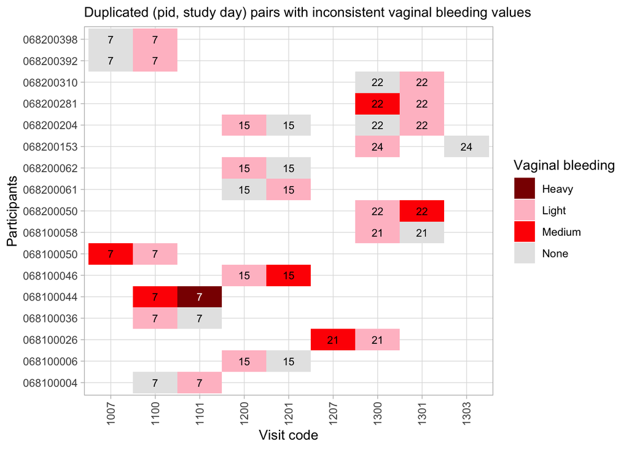

```r
bleeding |>
  select(pid, study_day, visit_code, vaginal_bleeding) |>
  dplyr::count(pid, study_day) |>
  filter(n > 1) |>
  left_join(bleeding, by = c("pid", "study_day")) |>
  group_by(pid, study_day) |>
  filter(n_distinct(vaginal_bleeding, na.rm = TRUE) > 1) |>
  ggplot() +
  aes(x = visit_code, y = pid, fill = vaginal_bleeding) +
  geom_tile() +
  geom_text(
    aes(
      label = study_day,
      col = ifelse(vaginal_bleeding == "Heavy", "white", "black")
    ),
    size = 3
  ) +
  scale_fill_manual(
    "Vaginal bleeding",
    values = c(
      "None" = "grey90",
      "Light" = "pink",
      "Medium" = "red",
      "Heavy" = "red4"
    )
  ) +
  scale_color_identity() +
  theme(axis.text.x = element_text(angle = 90, hjust = 1, vjust = 0.5)) +
  labs(
    x = "Visit code",
    y = "Participants",
    subtitle = "Duplicated (pid, study day) pairs with inconsistent vaginal bleeding values"
  )
```

```r
duplicated_bleeding <-
  bleeding |>
  dplyr::count(pid, study_day) |>
  filter(n > 1) |>
  left_join(bleeding, by = c("pid", "study_day")) |>
  group_by(pid, study_day) |>
  filter(n_distinct(vaginal_bleeding, na.rm = TRUE) > 1) |>
  ungroup() |>
  pull(pid) |>
  unique()
```

We will create a confusion matrix to evaluate, when there are duplicates in `study_day`, to check if the values are mostly the same or different.

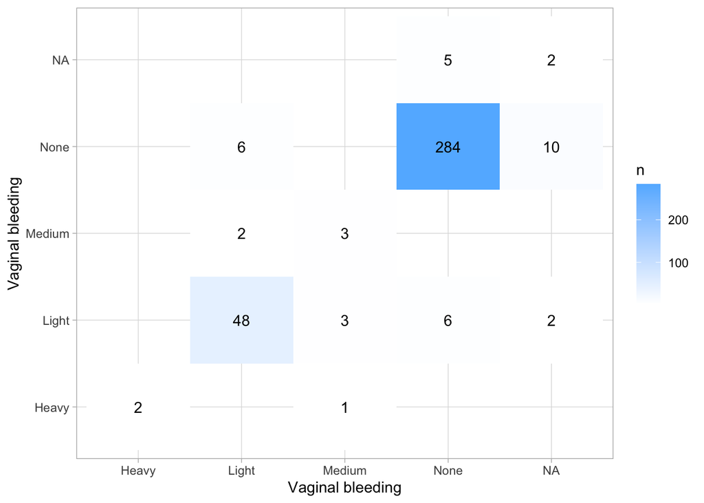

```r
tmp <-
  bleeding |>
  group_by(pid, study_day) |>
  filter(n() > 1) |>
  ungroup()

vb_pairs <-
  tmp |>
  group_by(pid, study_day) |>
  mutate(dup_id = row_number()) |>
  ungroup() |>
  select(pid, study_day, dup_id, vaginal_bleeding) |>
  tidyr::pivot_wider(
    names_from = dup_id,
    values_from = vaginal_bleeding,
    names_prefix = "vb_"
  )

vb_counts <- vb_pairs |>
  dplyr::count(vb_1, vb_2)

vb_counts |>
  ggplot() +
  aes(x = vb_1, y = vb_2) +
  geom_tile(aes(fill = n)) +
  geom_text(aes(label = n)) +
  scale_fill_gradient(low = "white", high = "steelblue1") +
  labs(x = "Vaginal bleeding", y = "Vaginal bleeding")
```

Now to keep only one unique value of study day, we will always take the heaviest bleeding, i.e. we always take the highest value between the two: Blank < None < Light < Medium < Heavy.

Only participant 068200247 has NA values for both vaginal bleeding duplicates on the same study day. Since the corresponding `study_day` value is −11 and the analysis starts at day 0, this observation was added to the excluded values.

```r
# bleeding <-
#   bleeding |>
#   group_by(pid, study_day) |>
#   mutate(
#     vaginal_bleeding = case_when(
#       "Heavy" %in% vaginal_bleeding ~ ifelse(vaginal_bleeding == "Heavy", "Heavy", "Excluded"),
#       "Medium" %in% vaginal_bleeding ~ ifelse(vaginal_bleeding == "Medium", "Medium", "Excluded"),
#       "Light" %in% vaginal_bleeding ~ ifelse(vaginal_bleeding == "Light", "Light", "Excluded"),
#       "None" %in% vaginal_bleeding ~ ifelse(vaginal_bleeding == "None", "None", "Excluded"),
#       "Blank" %in% vaginal_bleeding ~ ifelse(vaginal_bleeding == "Blank", "Blank", "Excluded"),
#       TRUE ~ NA_character_
#     ),
#     vaginal_bleeding = if_else(
#       duplicated(vaginal_bleeding) & !is.na(vaginal_bleeding), "Excluded", vaginal_bleeding
#     )
#   ) |>
#   ungroup()

bleeding <- bleeding |>
  group_by(pid, study_day) |>
  mutate(
    vaginal_bleeding = case_when(
      any(vaginal_bleeding == "Heavy", na.rm = TRUE) ~
        if_else(vaginal_bleeding == "Heavy", "Heavy", "Excluded"),

      any(vaginal_bleeding == "Medium", na.rm = TRUE) ~
        if_else(vaginal_bleeding == "Medium", "Medium", "Excluded"),

      any(vaginal_bleeding == "Light", na.rm = TRUE) ~
        if_else(vaginal_bleeding == "Light", "Light", "Excluded"),

      any(vaginal_bleeding == "None", na.rm = TRUE) ~
        if_else(vaginal_bleeding == "None", "None", "Excluded"),

      any(vaginal_bleeding == "Blank", na.rm = TRUE) ~
        if_else(vaginal_bleeding == "Blank", "Blank", "Excluded"),

      TRUE ~ NA_character_
    ),
    vaginal_bleeding = if_else(
      !is.na(vaginal_bleeding) & duplicated(vaginal_bleeding),
      "Excluded",
      vaginal_bleeding
    )
  ) |>
  ungroup()
```

```r
bleeding |>
  filter(randomized) |>
  select(pid, study_day, visit_code, vaginal_bleeding) |>
  filter(pid %in% duplicated_bleeding) |>
  dplyr::count(pid, study_day) |>
  filter(n > 1) |>
  left_join(bleeding, by = c("pid", "study_day")) |>
  group_by(pid, study_day) |>
  filter(n_distinct(vaginal_bleeding, na.rm = TRUE) > 1) |>
  ggplot() +
  aes(x = visit_code, y = pid, fill = vaginal_bleeding) +
  geom_tile() +
  geom_text(
    aes(
      label = study_day,
      col = ifelse(vaginal_bleeding == "Heavy", "white", "black")
    ),
    size = 2
  ) +
  scale_fill_manual(
    "Vaginal bleeding",
    values = c(
      "Excluded" = "yellow",
      "None" = "grey90",
      "Light" = "pink",
      "Medium" = "red",
      "Heavy" = "red4"
    )
  ) +
  scale_color_identity() +
  theme(
    axis.text.x = element_text(angle = 90, hjust = 1, vjust = 0.5)
  ) +
  labs(x = "Visit code", y = "Participant")
```

[output not shown]

We delete the rows of the duplicates (flagged by “Excluded”), keeping only the highest bleeding values.

```r
bleeding <-
  bleeding |>
  filter(vaginal_bleeding != "Excluded")
```

### Adding vaginal bleeding variable to the metadata

```r
mae@metadata$calc_vars_study_day <-
  mae@metadata$calc_vars_study_day |>
  left_join(
    bleeding |>
      select(pid, study_day, vaginal_bleeding),
    by = join_by(pid, study_day)
  )
```

## Vaginal insertions - deprecated

We explore the self-reported vaginal insertions variable by first performing an exploratory analysis for both daily and weekly responses, checking for missing values.

We have available the following information:

- From the daily CRF (CRF33):
  - `put_in_vagina_type`: daily self-reported vaginal insertions in the past 24 hours (between visits 1000 and 1500), excluding weekly visit codes. Participants were asked the question: “In the past 24 hours, have you put anything inside your vagina?”.
  - `N-put_in_vagina`: variable summarizing the number of vaginal insertions, excluding “Nothing” when participant reported having inserted nothing in their vagina in the past 24 hours.
- From the weekly CRF (CRF21):
  - `put_in_vagina_type`: weekly self-reported vaginal insertions in the past 24 hours (between visits 1000 and 1500). Participants were asked the question: “Did you put anything in your vagina in the past 24 hours?”.

```r
vaginal_insertions <-
  visits_crfs_merged |>
  select(
    uid,
    pid,
    visit_code,
    study_day,
    visit_type,
    site,
    randomized,
    n_put_in_vagina,
    put_in_vagina_type.crf21
  )
```

### Daily responses

We first look at the daily responses from CRF33.

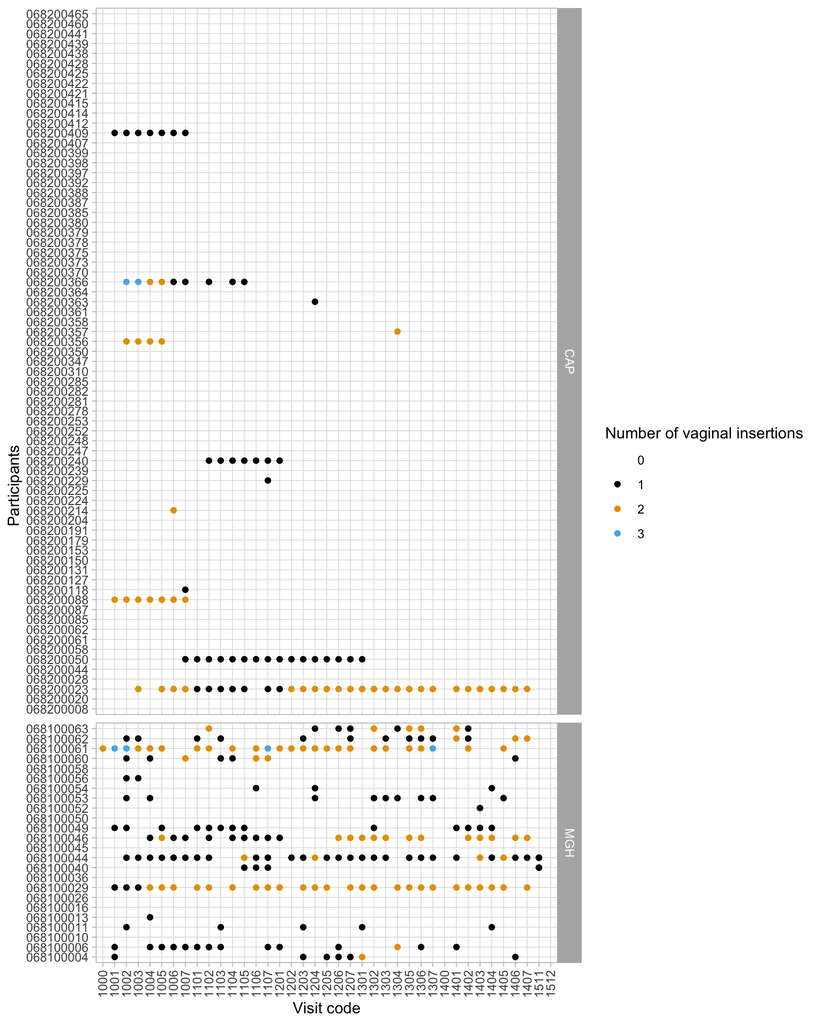

```r
vaginal_insertions |>
  filter(!is.na(n_put_in_vagina)) |>
  filter(randomized) |>
  ggplot() +
  aes(
    x = visit_code |> factor(),
    y = pid,
    col = n_put_in_vagina |> factor()
  ) +
  geom_point() +
  facet_grid(site ~ ., scales = "free_y", space = "free_y") +
  scale_color_manual(
    "Number of vaginal insertions",
    values = c(
      "0" = "transparent",
      "1" = "black",
      "2" = "#E69F00",
      "3" = "#56B4E9"
    )
  ) +
  scale_y_discrete(drop = FALSE) +
  theme(
    axis.text.x = element_text(angle = 90, hjust = 1, vjust = 0.5)
  ) +
  labs(
    x = "Visit code",
    y = "Participants"
  )
```

### Weekly responses

We also look at the weekly responses from CRF21. We can see that for this CRF, the variable `n_put_in_vagina` is not available. Thus, we will first create this variable.

```r
vaginal_insertions <-
  vaginal_insertions |>
  mutate(
    put_in_vagina_type.crf21 = put_in_vagina_type.crf21 |>
      str_replace_all("none_of_the_above", "nothing") |>
      str_replace_all("put_other", "other") |>
      str_replace_all("_", " ") |>
      str_to_sentence(),

    n_put_in_vagina.crf21 = case_when(
      is.na(put_in_vagina_type.crf21) ~ NA_integer_,
      put_in_vagina_type.crf21 == "" ~ 0L,
      TRUE ~ put_in_vagina_type.crf21 |>
        str_split(",\\s*") |>
        map_int(~ sum(!str_to_lower(.x) %in% "nothing"))
    )
  ) |>
  dplyr::rename(n_put_in_vagina.crf33 = n_put_in_vagina)
```

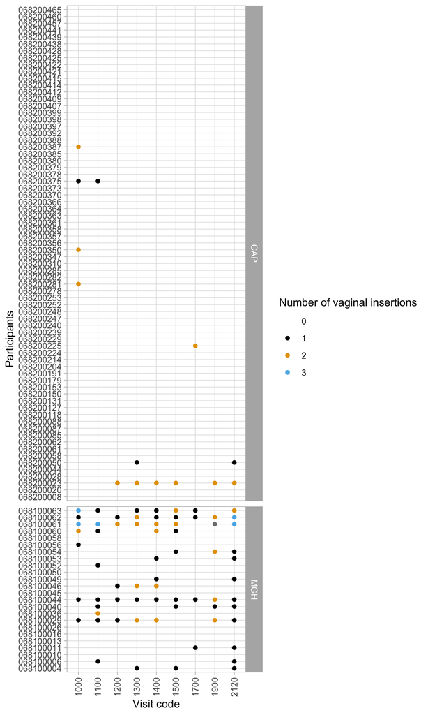

```r
vaginal_insertions |>
  filter(randomized) |>
  filter(!is.na(n_put_in_vagina.crf21)) |>
  ggplot() +
  aes(
    x = visit_code |> factor(),
    y = pid,
    col = n_put_in_vagina.crf21 |> factor()
  ) +
  geom_point() +
  facet_grid(site ~ ., scales = "free_y", space = "free_y") +
  scale_color_manual(
    "Number of vaginal insertions",
    values = c(
      "0" = "transparent",
      "1" = "black",
      "2" = "#E69F00",
      "3" = "#56B4E9"
    )
  ) +
  scale_y_discrete(drop = FALSE) +
  theme(
    axis.text.x = element_text(angle = 90, hjust = 1, vjust = 0.5)
  ) +
  labs(
    x = "Visit code",
    y = "Participants"
  )
```

### Harmonization of weekly and daily responses

In this section, we merge the information for `n_put_in_vagina` from the daily CRF33 and the weekly CRF21 into one single variable `n_put_in_vagina`.

```r
vaginal_insertions <-
  vaginal_insertions |>
  mutate(
    n_put_in_vagina = coalesce(n_put_in_vagina.crf33, n_put_in_vagina.crf21)
  )
```

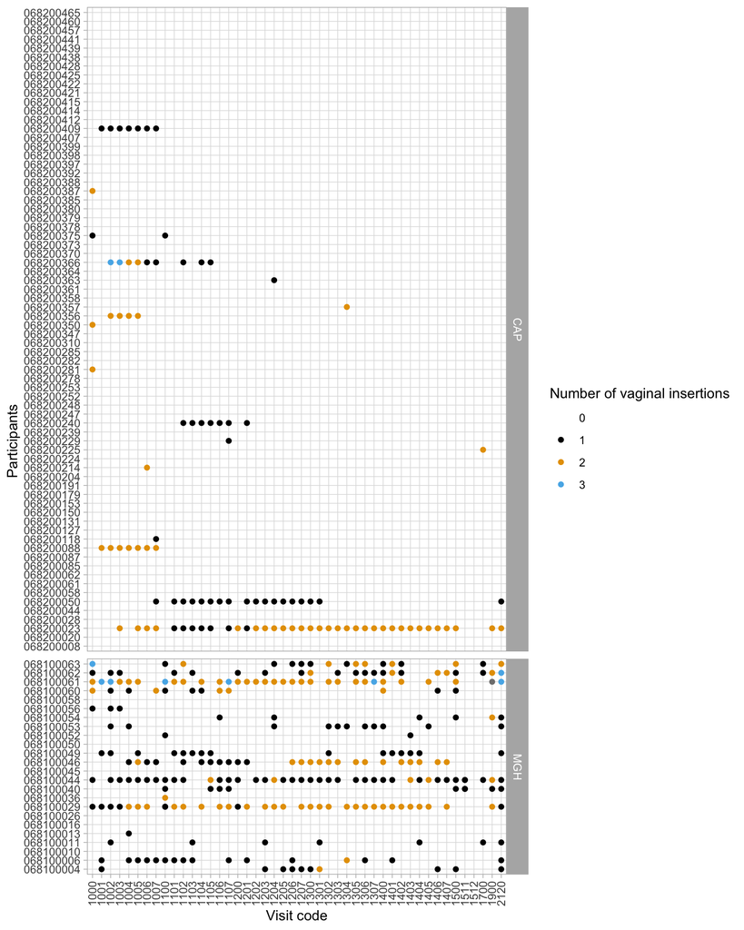

```r
vaginal_insertions |>
  filter(!is.na(n_put_in_vagina)) |>
  filter(randomized) |>
  ggplot() +
  aes(
    x = visit_code |> factor(),
    y = pid,
    col = n_put_in_vagina |> factor()
  ) +
  geom_point() +
  facet_grid(site ~ ., scales = "free_y", space = "free_y") +
  scale_color_manual(
    "Number of vaginal insertions",
    values = c(
      "0" = "transparent",
      "1" = "black",
      "2" = "#E69F00",
      "3" = "#56B4E9"
    )
  ) +
  scale_y_discrete(drop = FALSE) +
  theme(
    axis.text.x = element_text(angle = 90, hjust = 1, vjust = 0.5)
  ) +
  labs(
    x = "Visit code",
    y = "Participants"
  )
```

There are some missing values in `n_put_in_vagina`, we replace them with 0.

```r
vaginal_insertions <-
  vaginal_insertions |>
  mutate(
    n_put_in_vagina = case_when(
      as.character(n_put_in_vagina) %in% c("", NA) ~ "0",
      TRUE ~ as.character(n_put_in_vagina)
    )
  )
```

### Deleting duplicate values

As for the previous variable, some values are duplicated. We will remove these duplicates by keeping only the highest value for each participant on each study day.

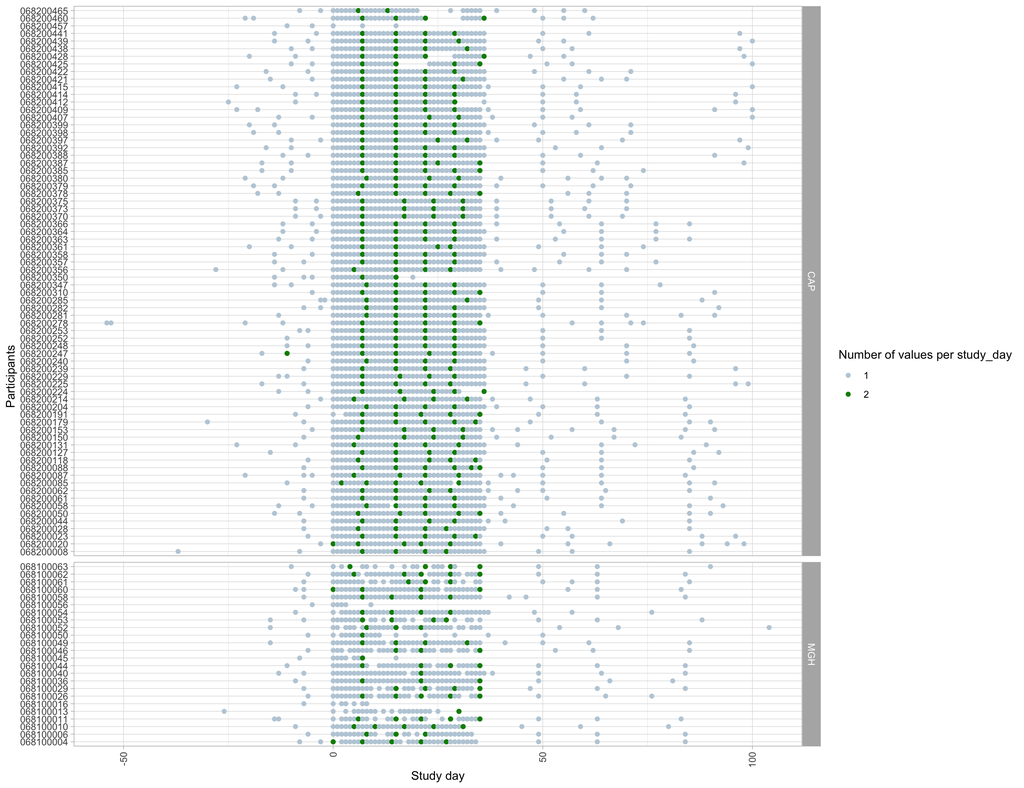

```r
vaginal_insertions |>
  filter(!is.na(n_put_in_vagina)) |>
  filter(randomized) |>
  arrange(pid, study_day) |>
  group_by(pid, study_day) |>
  mutate(n_duplicates = n()) |>
  ggplot() +
  aes(
    x = study_day,
    y = pid,
    col = n_duplicates |> as.character()
  ) +
  geom_point() +
  facet_grid(site ~ ., scales = "free_y", space = "free_y") +
  scale_color_manual(
    "Number of values per study_day",
    values = c(
      "0" = "transparent",
      "1" = "#bdcedb",
      "2" = "green4",
      "3" = "orange"
    )
  ) +
  scale_y_discrete(drop = FALSE) +
  theme(
    axis.text.x = element_text(angle = 90, hjust = 1, vjust = 0.5)
  ) +
  labs(
    x = "Study day",
    y = "Participants"
  )
```

The graph shows that most duplicates come from weekly samples, as expected from the study protocol. We’ll first plot confusion matrices to see if these duplicates mostly agree with each other.

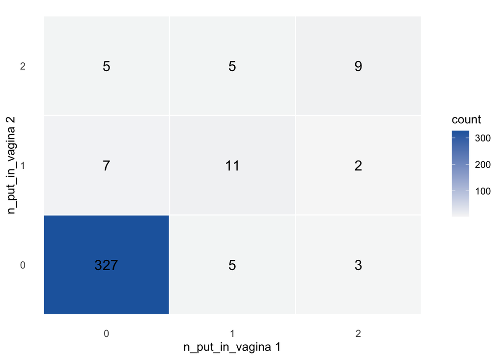

```r
duplicates <-
  vaginal_insertions |>
  select(pid, study_day, n_put_in_vagina) |>
  arrange(pid, study_day) |>
  group_by(pid, study_day) |>
  filter(n() == 2) |>
  mutate(duplicate_nb = row_number()) |>
  ungroup() |>
  pivot_wider(
    names_from = duplicate_nb,
    values_from = n_put_in_vagina,
    names_prefix = "n_put_in_vagina_"
  ) |>
  select(n_put_in_vagina_1, n_put_in_vagina_2)

tab <- table(duplicates$n_put_in_vagina_1, duplicates$n_put_in_vagina_2)

tab_df <- as.data.frame(tab)
names(tab_df) <- c("n_put_in_vagina_1", "n_put_in_vagina_2", "freq")

ggplot(tab_df, aes(x = n_put_in_vagina_1, y = n_put_in_vagina_2, fill = freq)) +
  geom_tile(color = "white", linewidth = 0.5) +
  geom_text(aes(label = freq), color = "black", size = 5) +
  scale_fill_gradient(low = "#f7f7f7", high = "#2166ac", name = "count") +
  labs(
    x = "n_put_in_vagina 1",
    y = "n_put_in_vagina 2"
  ) +
  theme_minimal(base_size = 12) +
  theme(
    plot.title = element_text(hjust = 0.5, face = "bold"),
    axis.text = element_text(size = 10),
    panel.grid = element_blank(),
    legend.position = "right"
  )
```

We see that most duplicate values agreed with each other.

We’ll now remove duplicates using `slice_max()` (so we keep the highest `n_put_in_vagina` values).

```r
vaginal_insertions <-
  vaginal_insertions |>
  select(uid, pid, study_day, visit_type, n_put_in_vagina) |>
  group_by(pid, study_day) |>
  slice_max(order_by = n_put_in_vagina, with_ties = FALSE)
```

### Adding the vaginal insertion variable to the metadata

We add the summary variables for vaginal insertion to the `calc_vars_study_day` table in the metadata of the `mae` object.

```r
mae@metadata$calc_vars_study_day <-
  mae@metadata$calc_vars_study_day |>
  left_join(
    vaginal_insertions |>
      select(pid, study_day, n_put_in_vagina),
    by = join_by(pid, study_day)
  )
```

## Vaginal insertions

```r
vaginal_insertions <-
  bind_rows(
    mae@metadata$crf_data_clean$crf33 |>
      select(pid, uid, put_in_vagina_type) |>
      mutate(crf = 33),
    mae@metadata$crf_data_clean$crf21 |>
      select(pid, uid, put_in_vagina_type) |>
      mutate(crf = 21)
  ) |>
  distinct()

vaginal_insertions_long <-
  vaginal_insertions |>
  mutate(
    put_in_vagina_type_split = str_split(put_in_vagina_type, ", ")
  ) |>
  unnest(put_in_vagina_type_split) |>
  mutate(
    put_in_vagina_type_split = ifelse(
      (put_in_vagina_type_split == "") | is.na(put_in_vagina_type_split),
      "unknown",
      put_in_vagina_type_split
    ) |>
      str_replace("put_other", "other") |>
      str_replace_all("_", " ") |>
      str_to_sentence()
  )

vaginal_insertions_long |> dplyr::count(put_in_vagina_type_split) |> arrange(-n)
```

```
# A tibble: 11 × 2
   put_in_vagina_type_split     n
   <chr>                    <int>
 1 Nothing                   2727
 2 None of the above          717
 3 Water                      265
 4 Fingers                    148
 5 Soap                        57
 6 Other                       28
 7 Tampons                     21
 8 Unknown                     14
 9 Sex toys                     8
10 Cream                        1
11 Douche                       1
```

```r
vaginal_insertions_summary <-
  vaginal_insertions_long |>
  filter(
    !(put_in_vagina_type_split %in%
      c("Nothing", "Water", "None of the above", "Unknown", "Water"))
  ) |>
  group_by(pid, uid) |>
  summarize(
    n_put_in_vagina = put_in_vagina_type_split |> n_distinct(),
    .groups = "drop"
  ) |>
  arrange(-n_put_in_vagina)

vaginal_insertions_summary |>
  dplyr::count(n_put_in_vagina)
```

```
# A tibble: 3 × 2
  n_put_in_vagina     n
            <int> <int>
1               1   226
2               2    17
3               3     1
```

```r
# vaginal_insertions_wide <-
#   vaginal_insertions_long |>
#   mutate(tmp = TRUE) |>
#   pivot_wider(
#     names_from = put_in_vagina_type_split,
#     values_from = tmp,
#     values_fill = FALSE
#   )
```

```r
vaginal_insertions_summary <-
  vaginal_insertions_summary |>
  left_join(
    mae@colData |> as_tibble() |> select(uid, study_day) |> distinct(),
    by = join_by(uid)
  )

vaginal_insertions_summary <-
  vaginal_insertions_summary |>
  group_by(pid, study_day) |>
  summarize(n_put_in_vagina = max(n_put_in_vagina), .groups = "drop")
```

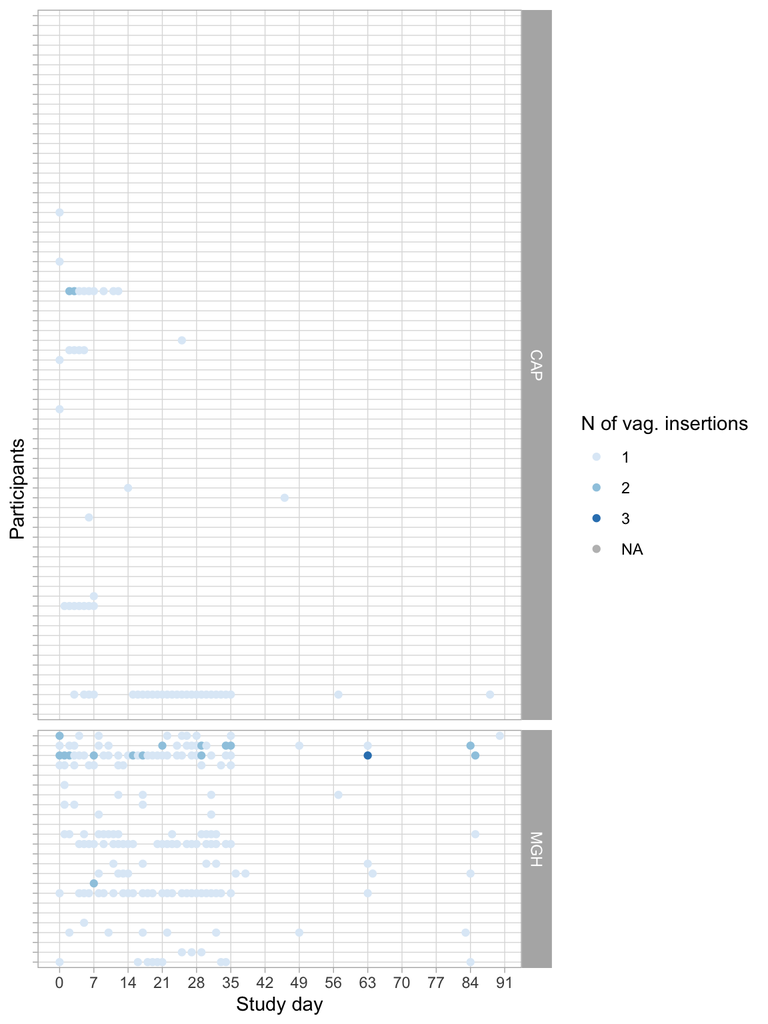

```r
vaginal_insertions_summary |>
  right_join(
    mae@colData |>
      as_tibble() |>
      select(pid, site, arm, randomized) |>
      distinct() |>
      filter(randomized),
    by = join_by(pid)
  ) |>
  filter(randomized) |>
  ggplot() +
  facet_grid(site ~ ., scales = "free", space = "free", drop = FALSE) +
  aes(x = study_day, y = pid, col = n_put_in_vagina |> factor()) +
  geom_point() +
  scale_color_brewer("N of vag. insertions", na.value = "gray") + #
  scale_x_continuous(
    "Study day",
    breaks = seq(0, 140, by = 7),
    minor_breaks = NULL
  ) +
  ylab("Participants") +
  theme(axis.text.y = element_blank())
```

```r
mae@metadata$calc_vars_study_day <-
  mae@metadata$calc_vars_study_day |>
  select(-any_of("n_put_in_vagina")) |>
  left_join(
    vaginal_insertions_summary |>
      select(pid, study_day, n_put_in_vagina),
    by = join_by(pid, study_day)
  ) |>
  mutate(n_put_in_vagina = n_put_in_vagina |> replace_na(0))
```

## Supplementary antibiotics

Antibiotic use was captured through two CRFs. CRF31 was completed at each clinical visit and recorded any concomitant medications reported by the participant. CRF20, part of the “Follow-up behaviour questionnaire”, asked participants whether they had used any of the following in the past week: oral probiotic, vaginal probiotic, oral antibiotic, vaginal antibiotic, oral yeast medication, vaginal yeast medication, lubricant during sex, lubricant during masturbation or vibrator use, or none of the above.

### CRF 31 - Concomitant medications

CRF31 is not in the `visits_crfs_merged` or `participant_crfs_merged` datasets but in the `crf_data_clean` object because this CRF was in a different format.

Different variables are measured in CRF31 =

- `medication` : the name of the medication
- `route` : the route of administration (e.g., oral, vaginal)
- `indication` : the reason for taking the medication
- `frequency` : how often the medication was taken
- `med_start_relative_date` : the study day when the medication was started, relative to the date of randomization (day 0)
- `med_stop_relative_date` : the study day when the medication was stopped, relative to the date of randomization (day 0)

Here is the list of all the concomitant medications reported by the participants in CRF31, along with their counts. We only keep randomized participants for this analysis.

```r
crf31 <-
  metadata(mae)$crf_data_clean$crf31 |>
  left_join(
    colData(mae) |>
      as_tibble() |>
      select(pid, ITT, mITT, PP, randomized, site) |>
      distinct()
  ) |>
  filter(randomized)

# we create the pid label variable
crf31 <- crf31 |> mutate(pid_label = ifelse(!PP, paste("(*) ", pid), pid))

crf31 |>
  dplyr::count(medication) |>
  gt::gt(caption = "Concominant medication")
```

Concominant medication

| medication | n |
| --- | --- |
| DEPO PROVERA | 110 |
| METRONIDAZOLE | 43 |
| NUR-ISTERATE | 18 |
| AZITHROMYCIN | 11 |
| PETOGEN | 8 |
| NURISTERATE | 13 |
| FLAGYL | 5 |
| CLOTRIMAZOLE | 1 |
| CEFTRIAXONE | 5 |
| TRIPHASIL | 5 |
| BRUFEN | 12 |
| ALLERGEX | 10 |
| PARACETAMOL | 9 |
| FLUCONAZOLE | 8 |
| OVRAL | 8 |
| PANADO | 7 |
| NORDETTE | 1 |
| METRONIDAZOLE 500MG | 4 |
| CETIRIZINE | 1 |
| CIPROFLOXACIN | 1 |
| LOPERAMIDE | 3 |
| URIZONE | 2 |
| AMOXICILLIN | 2 |
| AUGMENTIN | 2 |
| FLUCONAZOLE 150 MG | 2 |
| HYDROCORTISONE CREAM | 2 |
| METRONIDAZOLE 500MG TAB | 2 |
| MONISTAT CREAM | 2 |
| ACYCLOVIR | 1 |
| ALBUTEROL | 1 |

[output cut: 97 more lines]

The different route are

```r
crf31 |>
  filter(!is.na(route)) |>
  dplyr::count(route) |>
  mutate(
    route_description = case_when(
      route == "IM" ~ "Intramuscular",
      route == "PO" ~ "Oral",
      route == "VAG" ~ "Vaginal",
      route == "TOP" ~ "Topical",
      route == "IHL" ~ "Inhalation",
      route == "IV" ~ "Intravenous",
      route == "SC" ~ "Subcutaneous",
      route == "REC" ~ "Rectal",
      TRUE ~ route
    )
  ) |>
  select(route, route_description, n) |>
  arrange(desc(n)) |>
  gt::gt(caption = "Route of administration")
```

Route of administration

| route | route_description | n |
| --- | --- | --- |
| PO | Oral | 200 |
| IM | Intramuscular | 162 |
| TOP | Topical | 18 |
| VAG | Vaginal | 6 |
| IV | Intravenous | 4 |
| IHL | Inhalation | 3 |
| SC | Subcutaneous | 1 |
| Blank | Blank | 1 |
| REC | Rectal | 1 |

And the different frequency are

```r
crf31 |>
  filter(!is.na(frequency)) |>
  dplyr::count(frequency) |>
  mutate(
    frequency_description = case_when(
      frequency == "Stat" ~ "Immediately and only once",
      frequency == "BID" ~ "Twice a day",
      frequency == "QD" ~ "Once a day",
      frequency == "PRN" ~ "As needed",
      frequency == "QD" ~ "Once a day",
      frequency == "TID" ~ "Three times a day",
      frequency == "Nocte" ~ "At night",
      frequency == "QID" ~ "Four times a day",
      TRUE ~ frequency
    )
  ) |>
  select(frequency, frequency_description, n) |>
  arrange(desc(n)) |>
  gt::gt(caption = "Frequency of administration")
```

Frequency of administration

| frequency | frequency_description | n |
| --- | --- | --- |
| Stat | Immediately and only once | 184 |
| BID | Twice a day | 68 |
| QD | Once a day | 47 |
| PRN | As needed | 32 |
| TID | Three times a day | 26 |
| Other | Other | 17 |
| Nocte | At night | 13 |
| QID | Four times a day | 8 |
| Blank | Blank | 1 |

Some of those medications are antibiotics, which may have an impact on the vaginal microbiome and thus on the primary outcome. We look at the number of participants who took these antibiotics and when they took them.

```r
antibiotics <- c(
  "METRONIDAZOLE",
  "FLAGYL",
  "NITROFURANTOIN",
  "MACROBID",
  "AZITHROMYCIN",
  "PENICILLIN",
  "AMOXICILLIN",
  "AUGMENTIN",
  "CIPROBAY",
  "CIPROFLOXACIN",
  "CEFTRIAXONE",
  "DOXYCYCLINE",
  "FOSFOMYCIN",
  "BENZATHINE",
  "URIZONE"
)

# crf31 |>
#   filter(str_detect(medication, paste(antibiotics, collapse = "|"))) |>
#   dplyr::count(medication) |>
#   gt::gt(caption="Supplementary antibiotics")

crf31 |>
  filter(str_detect(medication, paste(antibiotics, collapse = "|"))) |>
  summarise(
    n = n(),
    n_PP = sum(PP, na.rm = TRUE),
    .by = medication
  ) |>
  arrange(desc(n)) |>
  gt::gt(caption = "Supplementary antibiotics")
```

Supplementary antibiotics

| medication | n | n_PP |
| --- | --- | --- |
| METRONIDAZOLE | 43 | 40 |
| AZITHROMYCIN | 11 | 10 |
| FLAGYL | 5 | 5 |
| CEFTRIAXONE | 5 | 5 |
| METRONIDAZOLE 500MG | 4 | 0 |
| METRONIDAZOLE 500MG TAB | 2 | 2 |
| AMOXICILLIN | 2 | 2 |
| AUGMENTIN | 2 | 2 |
| URIZONE | 2 | 2 |
| METRONIDAZOLE 500 MG TAB | 1 | 1 |
| METRONIDAZOLE (FLAGYL) 500MG | 1 | 0 |
| MACROBID(NITROFURANTOIN) 100MG | 1 | 1 |
| NITROFURANTOIN | 1 | 0 |
| METRONIDAZOLE 10MG | 1 | 0 |
| METRONIDAZOLE (METROGEL) 0.75 % | 1 | 0 |
| BENZATHINE BENZYLPENICILLIN | 1 | 1 |
| CIPROFLOXACIN | 1 | 0 |
| BENZATHINE BENZYL PENICILLIN | 1 | 0 |
| FOSFOMYCIN | 1 | 0 |

We create a dictionnary built from distinct combinaition of `medication` and `route` to categorize the antibiotics into different classes. This dictionnary contains the following variables:

- `medication` : the name of the medication
- `route` : the route of administration (e.g., oral, vaginal)
- `route_description` : a description of the route of administration
- `is_abx` : a binary variable indicating whether the medication is an antibiotic or not
- `abx_compound` : the class of antibiotic compound (e.g., Metronidazole, Penicillins, etc.) or “Non ABX” if the medication is not an antibiotic
- `abx_cat`

```r
dictionnary <-
  crf31 |>
  select(medication, route) |>
  distinct() |>
  mutate(
    route_description = case_when(
      route == "IM" ~ "Intramuscular",
      route == "PO" ~ "Oral",
      route == "VAG" ~ "Vaginal",
      route == "TOP" ~ "Topical",
      route == "IHL" ~ "Inhalation",
      route == "IV" ~ "Intravenous",
      route == "SC" ~ "Subcutaneous",
      route == "REC" ~ "Rectal",
      TRUE ~ route
    ),
    is_abx = str_detect(medication, paste(antibiotics, collapse = "|")),
    abx_compound = case_when(
      str_detect(
        medication,
        regex("METRONIDAZOLE|FLAGYL", ignore_case = TRUE)
      ) ~ "Metronidazole",
      str_detect(
        medication,
        regex("NITROFURANTOIN|MACROBID", ignore_case = TRUE)
      ) ~ "Nitrofurans",
      str_detect(
        medication,
        regex("AZITHRO", ignore_case = TRUE)
      ) ~ "Macrolides",
      str_detect(
        medication,
        regex("PENICILLIN|AMOXICILLIN|AUGMENTIN", ignore_case = TRUE)
      ) ~ "Penicillins",
      str_detect(
        medication,
        regex("CIPROFLOXACIN|CIPROBAY", ignore_case = TRUE)
      ) ~ "Fluoroquinolones",
      str_detect(
        medication,
        regex("CEFTRIAXONE", ignore_case = TRUE)
      ) ~ "Cephalosporins",
      str_detect(
        medication,
        regex("DOXYCYCLINE", ignore_case = TRUE)
      ) ~ "Tetracyclines",
      str_detect(
        medication,
        regex("FOSFOMYCIN|URIZONE", ignore_case = TRUE)
      ) ~ "Fosfomycin",
      str_detect(
        medication,
        regex("BENZANINE", ignore_case = TRUE)
      ) ~ "Benzanines",
      TRUE ~ "Non ABX"
    ),
    abx_cat = case_when(
      is_abx & abx_compound == "Metronidazole" & route == "PO" ~ "cm_oral_mtz",
      is_abx & abx_compound == "Metronidazole" & route == "VAG" ~ "cm_vag_mtz",
      is_abx &
        abx_compound == "Metronidazole" &
        !(route %in% c("PO", "VAG")) ~ "cm_oral_mtz", #other_route_mtz
      is_abx & abx_compound != "Metronidazole" ~ "cm_other_abx",

      #is_abx & abx_compound != "Metronidazole" & route == "PO" ~ "oral_other_abx",
      #is_abx & abx_compound != "Metronidazole" & route == "VAG" ~ "vaginal_other_abx",
      #is_abx & abx_compound != "Metronidazole" & !(route %in% c("PO", "VAG")) ~ "other_route_other_abx",

      TRUE ~ "Non ABX"
    )
  )

dictionnary |> arrange(-is_abx, abx_compound) |> gt()
```

| medication | route | route_description | is_abx | abx_compound | abx_cat |
| --- | --- | --- | --- | --- | --- |
| CEFTRIAXONE | IM | Intramuscular | TRUE | Cephalosporins | cm_other_abx |
| CIPROFLOXACIN | PO | Oral | TRUE | Fluoroquinolones | cm_other_abx |
| FOSFOMYCIN | PO | Oral | TRUE | Fosfomycin | cm_other_abx |
| URIZONE | PO | Oral | TRUE | Fosfomycin | cm_other_abx |
| AZITHROMYCIN | PO | Oral | TRUE | Macrolides | cm_other_abx |
| METRONIDAZOLE 500MG TAB | PO | Oral | TRUE | Metronidazole | cm_oral_mtz |
| METRONIDAZOLE 500 MG TAB | PO | Oral | TRUE | Metronidazole | cm_oral_mtz |
| METRONIDAZOLE (FLAGYL) 500MG | PO | Oral | TRUE | Metronidazole | cm_oral_mtz |
| METRONIDAZOLE 500MG | PO | Oral | TRUE | Metronidazole | cm_oral_mtz |
| METRONIDAZOLE 10MG | PO | Oral | TRUE | Metronidazole | cm_oral_mtz |
| METRONIDAZOLE (METROGEL) 0.75 % | VAG | Vaginal | TRUE | Metronidazole | cm_vag_mtz |
| FLAGYL | Blank | Blank | TRUE | Metronidazole | cm_oral_mtz |
| METRONIDAZOLE | PO | Oral | TRUE | Metronidazole | cm_oral_mtz |
| FLAGYL | PO | Oral | TRUE | Metronidazole | cm_oral_mtz |
| METRONIDAZOLE | IM | Intramuscular | TRUE | Metronidazole | cm_oral_mtz |
| MACROBID(NITROFURANTOIN) 100MG | PO | Oral | TRUE | Nitrofurans | cm_other_abx |
| NITROFURANTOIN | PO | Oral | TRUE | Nitrofurans | cm_other_abx |
| AMOXICILLIN | PO | Oral | TRUE | Penicillins | cm_other_abx |
| BENZATHINE BENZYLPENICILLIN | IM | Intramuscular | TRUE | Penicillins | cm_other_abx |
| AUGMENTIN | PO | Oral | TRUE | Penicillins | cm_other_abx |
| BENZATHINE BENZYL PENICILLIN | IM | Intramuscular | TRUE | Penicillins | cm_other_abx |
| JUNEL FE 1/20 | PO | Oral | FALSE | Non ABX | Non ABX |
| FLUCONAZOLE | PO | Oral | FALSE | Non ABX | Non ABX |
| DEPOT MEDROXYPROGESTERONE ACETATE (DEPO PROVERA) | IM | Intramuscular | FALSE | Non ABX | Non ABX |
| ALESSE (LEVONORGESTREL-ETHNIC ESTRADIOL 01-0.02 MG) | PO | Oral | FALSE | Non ABX | Non ABX |
| ALBUTEROL | IHL | Inhalation | FALSE | Non ABX | Non ABX |
| TRIAMCINOLONE 0.5% OINTMENT | TOP | Topical | FALSE | Non ABX | Non ABX |
| LEVONORGESTREL-ETHINYL ESTRADIOL. 01-0.02 MG PER TABLET | PO | Oral | FALSE | Non ABX | Non ABX |
| HYDROCORTISONE 2% | TOP | Topical | FALSE | Non ABX | Non ABX |
| ALBUTEROL INHALER | IHL | Inhalation | FALSE | Non ABX | Non ABX |

[output cut: 100 more lines]